# Climate-Livestock Dynamics in Somalia

Yale University | Environmental Data Science Capstone

Mohamed Said

2026-02-01

# 1 Abstract

Pastoral livestock systems in Somalia are highly dependent on rainfall because precipitation controls pasture availability, water resources, and rangeland productivity. However, rainfall in Somalia is characterized by strong interannual variability and frequent droughts, raising concerns about how climate fluctuations may influence livestock population dynamics. This study investigates the relationship between long-term rainfall variability and livestock stocks in Somalia from 1981 to 2024.

The analysis integrates satellite-derived rainfall data from the Climate Hazards Group InfraRed Precipitation with Station Data (CHIRPS v3) with national livestock stock statistics from the FAOSTAT database. Rainfall rasters were processed using spatial methods to generate national and regional rainfall summaries, rainfall anomalies, and spatial variability measures. Exploratory data analysis was used to examine rainfall distributions, drought years, and spatial rainfall patterns across Somalia’s administrative regions. Livestock population trends for camels, cattle, goats, and sheep were evaluated using time-series indicators including year-over-year growth rates and indexed stock levels. To evaluate potential climate–livestock linkages, a generalized additive model (GAM) was estimated using national rainfall anomalies and lagged rainfall anomalies (0–2 years) as predictors of log-transformed livestock stocks.

Results show that Somalia’s rainfall regime is dominated by strong year-to-year variability rather than a significant long-term trend. Livestock trends differ by species, with camels showing a significant long-term increase, goats showing a substantial decline, cattle remaining relatively stable, and sheep displaying weaker downward tendencies. The GAM analysis indicates that species-specific long-term time dynamics explain most variation in livestock stocks, while national rainfall anomalies and their lagged effects provide limited additional explanatory power.

These findings suggest that livestock dynamics in Somalia are shaped by multiple interacting drivers beyond national rainfall variability alone, including socio-economic conditions, conflict, market forces, and pastoral mobility constraints. Improving climate resilience in Somalia’s pastoral systems therefore requires integrated monitoring of climate, livestock, and socio-economic factors.

# 2 Introduction

Pastoral livestock production is central to Somalia’s economy and rural livelihoods.Livestock contribute significantly to household income, food security, and national exports.

However, pastoral systems depend heavily on rainfall because precipitation determines rangeland productivity, pasture availability, and water access for livestock.

Somalia experiences highly variable rainfall with frequent droughts and occasional extreme wet years. These climate fluctuations may affect livestock survival, herd growth, and long-term livestock population dynamics. Understanding how rainfall variability relates to livestock stocks is therefore important for climate adaptation planning and sustainable pastoral management.

*Research question How do long-term rainfall trends influence density changes of goats, sheep, and camels across Somalia’s?.*

## 2.1 Data Sources

This analysis integrates three primary datasets:

1. **CHIRPS v3 rainfall data (1981–2024)**  
   Satellite-gauge rainfall estimates from the Climate Hazards Center that provide annual rainfall measurements across Africa at approximately 0.05° spatial resolution.
2. **FAOSTAT livestock stock data**  
   National livestock population estimates for Somalia including camels, cattle, goats, and sheep. FAOSTAT data were downloaded manually as a CSV from the FAO FAOSTAT portal (https://www.fao.org/faostat/en/) using the website’s Download/Export function after selecting Somalia, the relevant variables, and the study years.
3. **GADM administrative boundaries**  
   Vector shapefiles providing Somalia’s national, regional, and district boundaries.

These datasets allow rainfall patterns to be summarized spatially and linked with national livestock population time series.

## 2.2 Analytical Approach

The analysis follows five main steps:

1. **Rainfall preprocessing** CHIRPS annual rainfall rasters were downloaded for 1981–2024 and clipped to the Somalia national boundary.
2. **Rainfall summaries** National and regional mean rainfall statistics were calculated for each year.
3. **Exploratory data analysis** Rainfall anomalies, distributions, and spatial variability were examined.
4. **Livestock time-series analysis** FAOSTAT livestock stocks were analyzed using growth rates, index values, and trend tests.
5. **Climate–livestock modeling** A generalized additive model (GAM) was used to test whether rainfall anomalies (including lagged effects) are associated with livestock stock dynamics.

## 2.3 plot Somalia and the Administrative Regions of Somalia but

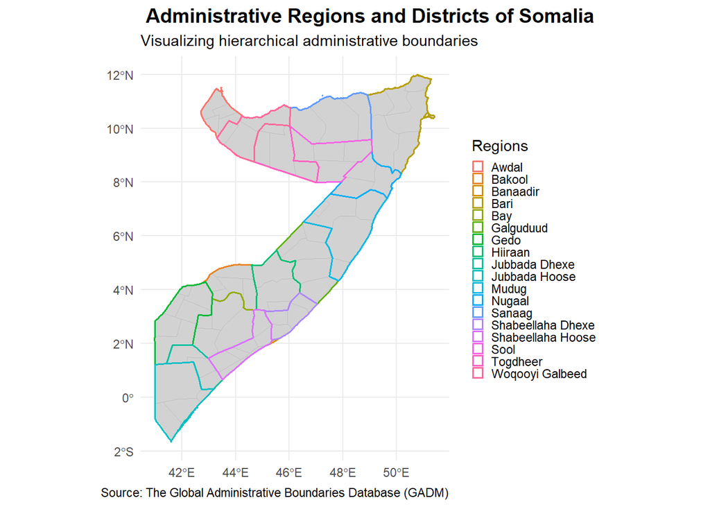

```r
# Plot the Somalia boundaries map
(Somali_map <- ggplot() +
  geom_sf(data = somalia_country, fill = "grey", color = "black", size = 0.5) +
  geom_sf(data = somalia_districts, color = "grey", size = 0.1, alpha = 0.5) +
  geom_sf(data = somalia_regions, aes(color = NAME_1), fill = NA, size = 0.6) +
  theme_minimal() +
  labs(title = " Administrative Regions and Districts of Somalia",
       subtitle = "Visualizing hierarchical administrative boundaries",
       caption = " Source: The Global Administrative Boundaries Database (GADM)",
       color = "Regions")+
   theme(
    legend.position = "right",
    legend.key.size = unit(0.3, "cm"),
    plot.title = element_text(face = "bold", size = 14)
  ))
```

```r
## download the chirps dataset

# CHIRPS v3 annual Africa data location
base_url <- "https://data.chc.ucsb.edu/products/CHIRPS/v3.0/annual/africa/tifs/"

years <- 1981:2024

# Download chirps into raw_data
for (y in years) {
  file_name <- paste0("chirps-v3.0.", y, ".tif")
  file_url <- paste0(base_url, file_name)
  file_dest <- file.path("raw_data","chirps", file_name)
  download.file(file_url, file_dest, mode = "wb")
}
```

Load the vector data files in the row folder using list.files and rename to Chirpsv3. Also work with new code to assign layers since the chirps data sets are stored in years from 1981 to 2024.

```r
# List all files
tif_files <- list.files(file.path("raw_data","chirps"), pattern="\\.tif$", full.names=TRUE)


# assignt to chirpsv3
chirpsv3 <- terra::rast(tif_files)

# Assign clean layer names (e.g., chirpsv3_1981, chirpsv3_1982, ...)
years <- 1981:2024
names(chirpsv3) <- paste0("chirpsv3_", years)

# Check the object
nlyr(chirpsv3)
```

```
## [1] 44
```

```r
res(chirpsv3)
```

```
## [1] 0.05 0.05
```

```r
names(chirpsv3)
```

```
##  [1] "chirpsv3_1981" "chirpsv3_1982" "chirpsv3_1983" "chirpsv3_1984"
##  [5] "chirpsv3_1985" "chirpsv3_1986" "chirpsv3_1987" "chirpsv3_1988"
##  [9] "chirpsv3_1989" "chirpsv3_1990" "chirpsv3_1991" "chirpsv3_1992"
## [13] "chirpsv3_1993" "chirpsv3_1994" "chirpsv3_1995" "chirpsv3_1996"
## [17] "chirpsv3_1997" "chirpsv3_1998" "chirpsv3_1999" "chirpsv3_2000"
## [21] "chirpsv3_2001" "chirpsv3_2002" "chirpsv3_2003" "chirpsv3_2004"
## [25] "chirpsv3_2005" "chirpsv3_2006" "chirpsv3_2007" "chirpsv3_2008"
## [29] "chirpsv3_2009" "chirpsv3_2010" "chirpsv3_2011" "chirpsv3_2012"
## [33] "chirpsv3_2013" "chirpsv3_2014" "chirpsv3_2015" "chirpsv3_2016"
## [37] "chirpsv3_2017" "chirpsv3_2018" "chirpsv3_2019" "chirpsv3_2020"
## [41] "chirpsv3_2021" "chirpsv3_2022" "chirpsv3_2023" "chirpsv3_2024"
```

# 3 calucalte the summary statitics fo the data

There is -9999 which is placeholder for the oceans pixels which has no CHIRPSV3 has not data. we will mask these values by replacing the -9999 to NA and dropping to select land bixelsn only

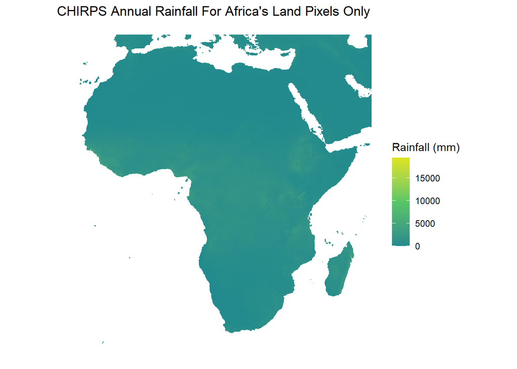

```r
# Plot the masked raster using ggplot2 with tidyterra
ggplot() +
  geom_spatraster(data = chirpsv3) +
    ggplot2::scale_fill_gradientn(
    colors = c("#228A8D", "#56C666", "#DDE31C"), # low -> high
    na.value = "transparent",
    name = "Rainfall (mm)"
  ) +
  theme_void() +
  labs(title = "CHIRPS Annual Rainfall For Africa's Land Pixels Only")
```

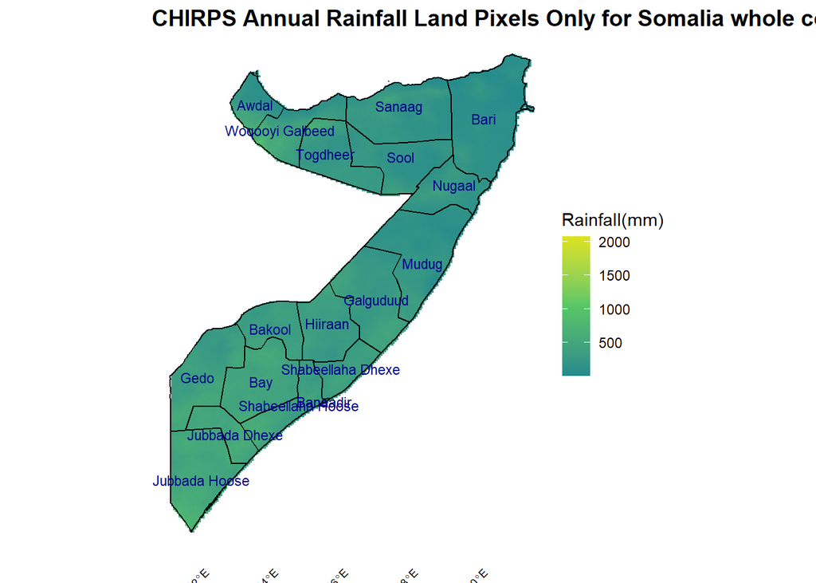

```r
# Plot the masked raster
ggplot() +
  geom_spatraster(data = chirps_SOM_terrestrial) +
 scale_fill_gradientn(
    colours = c("#228A8D", "#56C666", "#DDE31C"), # low -> high
    na.value = "transparent",
    name = "Rainfall(mm)" ) +
  geom_sf(data = somalia_regions, fill = NA, linewidth = 0.4, color = "black") +
  geom_sf_text(data = somalia_regions, aes(label = NAME_1 ), size = 3, color = "darkblue") +
  theme_void() +
  labs(title = "CHIRPS Annual Rainfall Land Pixels Only for Somalia whole country ")  +
  theme(
    strip.text = element_text(face = "bold", size = 9),
    plot.title = element_text(face = "bold", size = 14),
    axis.text.x = element_text(angle = 45, hjust = 1, size = 7)
  )
```

## 3.1 Somalia National Mean Rainfall Time Series (1981–2024)

This gives a one value per year (mean rainfall over Somalia).

```r
# Somalia mean rainfall per year (over all pixels)
som_ts_mean <- terra::global(chirps_SOM_terrestrial, fun = "mean", na.rm = TRUE)
som_ts_mean <- tibble(
  year = 1981:2024,
  mean_rain = as.numeric(som_ts_mean[,1])
)

knitr::kable(
  som_ts_mean,
  format = "html",
  caption = "Somalia national mean annual rainfall (CHIRPS v3), 1981–2024"
) %>%
  kableExtra::kable_styling(
    full_width = T,
    bootstrap_options = c("striped", "condensed", "hover")
  )
```

Somalia national mean annual rainfall (CHIRPS v3), 1981–2024

| year | mean_rain |
| --- | --- |
| 1981 | 452.4537 |
| 1982 | 461.2739 |
| 1983 | 268.8268 |
| 1984 | 256.5802 |
| 1985 | 290.1495 |
| 1986 | 284.1476 |
| 1987 | 385.8816 |
| 1988 | 340.0360 |
| 1989 | 372.7689 |
| 1990 | 336.8836 |
| 1991 | 320.6369 |
| 1992 | 266.9518 |
| 1993 | 269.3963 |
| 1994 | 421.3819 |
| 1995 | 283.5440 |
| 1996 | 227.7187 |
| 1997 | 784.2741 |
| 1998 | 267.4935 |
| 1999 | 241.2554 |
| 2000 | 278.2497 |
| 2001 | 228.2192 |
| 2002 | 325.3805 |
| 2003 | 296.2606 |
| 2004 | 316.7948 |
| 2005 | 267.0725 |
| 2006 | 438.5315 |
| 2007 | 310.8468 |
| 2008 | 282.2237 |
| 2009 | 287.2044 |
| 2010 | 301.5432 |
| 2011 | 330.3013 |
| 2012 | 379.6313 |
| 2013 | 417.3060 |
| 2014 | 273.4306 |
| 2015 | 386.7256 |
| 2016 | 209.1018 |
| 2017 | 279.6952 |
| 2018 | 384.3587 |
| 2019 | 478.1282 |
| 2020 | 367.1906 |
| 2021 | 250.9322 |
| 2022 | 214.1745 |
| 2023 | 545.3056 |
| 2024 | 303.3268 |

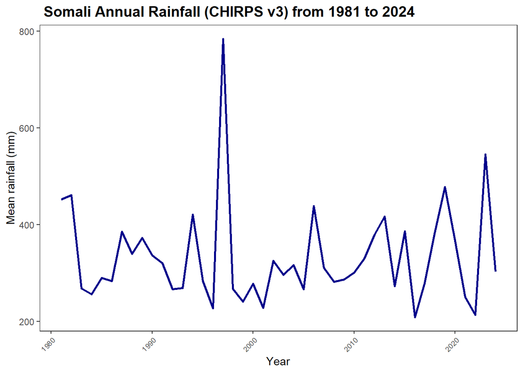

```r
#  time series Plot
ggplot(som_ts_mean, aes(year, mean_rain)) +
  geom_line(linewidth = 1, col = "darkblue") +
  theme_test() +
  labs(title = " Somali Annual Rainfall (CHIRPS v3) from 1981 to 2024",
       x = "Year", y = "Mean rainfall (mm)")  +
  theme(
    strip.text = element_text(face = "bold", size = 9),
    plot.title = element_text(face = "bold", size = 14),
    axis.text.x = element_text(angle = 45, hjust = 1, size = 7)
  )
```

*Map of the Somalia Mean Annual Rainfall (CHIRPS v3, 1981–2024 MEAN RASTER)*

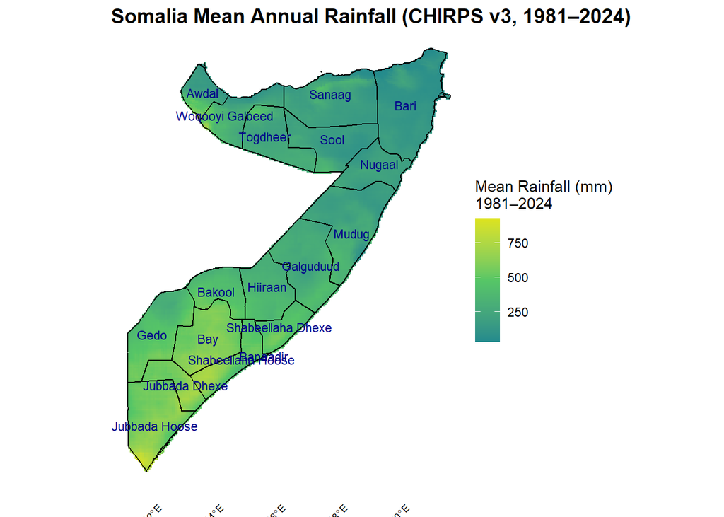

```r
# 1981–2024 MEAN RASTER (one layer)
chirps_SOM_mean_1981_2024 <- terra::app(chirps_SOM_terrestrial, fun = mean, na.rm = TRUE)

# Plot mean map + regions
ggplot() +
  geom_spatraster(data = chirps_SOM_mean_1981_2024) +
  scale_fill_gradientn(
    colours = c("#228A8D", "#56C666", "#DDE31C"),
    na.value = "transparent",
    name = "Mean Rainfall (mm)\n1981–2024"
  ) +
  geom_sf(data = somalia_regions, fill = NA, linewidth = 0.4, color = "black") +
  geom_sf_text(data = somalia_regions, aes(label = NAME_1), size = 3, color = "darkblue") +
  theme_void() +
  labs(title = "Somalia Mean Annual Rainfall (CHIRPS v3, 1981–2024)")  +
  theme(
    strip.text = element_text(face = "bold", size = 9),
    plot.title = element_text(face = "bold", size = 14),
    axis.text.x = element_text(angle = 45, hjust = 1, size = 7)
  )
```

## 3.2 Interannual Variability and Rainfall Anomalies

The anomaly series shows strong interannual variability with frequent switches between wet and dry years, indicating that Somalia’s national rainfall is dominated by year-to-year fluctuations. Extreme years stand out clearly: 1997 is the wettest outlier (anomaly ≈ +450.6 mm), while 2016 is among the driest years (anomaly ≈ −124.6 mm). Multi-year dry clusters are visible in the early 1990s (e.g., 1991–1993) and late 1990s–early 2000s (e.g., 1998–2001), while recent years remain highly variable, including strong wet anomalies in 2019 and 2023 and strong dry anomalies in 2021–2022. The anomaly (deviation from long-term mean) of Somalia since 1981

```r
som_ts_mean <- som_ts_mean %>%
  mutate(anomaly = mean_rain - mean(mean_rain, na.rm = TRUE))

datatable(som_ts_mean, rownames=FALSE, caption= "Somalia national mean annual rainfall (CHIRPS v3), 1981–2024")%>%
  DT::formatRound("mean_rain",4)
```

| year | mean_rain | anomaly |
| --- | --- | --- |
| 1981 | 452.4537138085437 | 118.7357658873959 |
| 1982 | 461.2738777536447 | 127.5559298324969 |
| 1983 | 268.8267688572437 | -64.89117906390408 |
| 1984 | 256.5802212393473 | -77.13772668180047 |
| 1985 | 290.1495044047156 | -43.56844351643218 |
| 1986 | 284.1475744162067 | -49.57037350494107 |
| 1987 | 385.8815652985221 | 52.16361737737429 |
| 1988 | 340.0359755252034 | 6.318027604055601 |
| 1989 | 372.7688986742547 | 39.05095075310692 |
| 1990 | 336.8835974857466 | 3.165649564598766 |

[output cut: 34 more lines]

```r
# lowest and highest rainfall years
extreme_rainfall_years <- som_ts_mean %>%
  filter(
    mean_rain == min(mean_rain, na.rm = TRUE) |
    mean_rain == max(mean_rain, na.rm = TRUE)
  ) %>%
  mutate(
    category = case_when(
      mean_rain == min(mean_rain, na.rm = TRUE) ~ "Lowest rainfall year",
      mean_rain == max(mean_rain, na.rm = TRUE) ~ "Highest rainfall year"
    )
  ) %>%
  select(category, year, mean_rain, anomaly)

extreme_rainfall_years %>%
  mutate(
    mean_rain = round(mean_rain, 4),
    anomaly = round(anomaly, 4)
  ) %>%
  knitr::kable(
    format = "html",
    rownames = FALSE,
    caption = "Somalia Lowest and Highest Annual Rainfall Years (CHIRPS v3), 1981–2024"
  ) %>%
  kableExtra::kable_styling(
    full_width = TRUE,
    bootstrap_options = c("striped", "condensed", "hover")
  )
```

Somalia Lowest and Highest Annual Rainfall Years (CHIRPS v3), 1981–2024

| category | year | mean_rain | anomaly |
| --- | --- | --- | --- |
| Highest rainfall year | 1997 | 784.2741 | 450.5562 |
| Lowest rainfall year | 2016 | 209.1018 | -124.6161 |

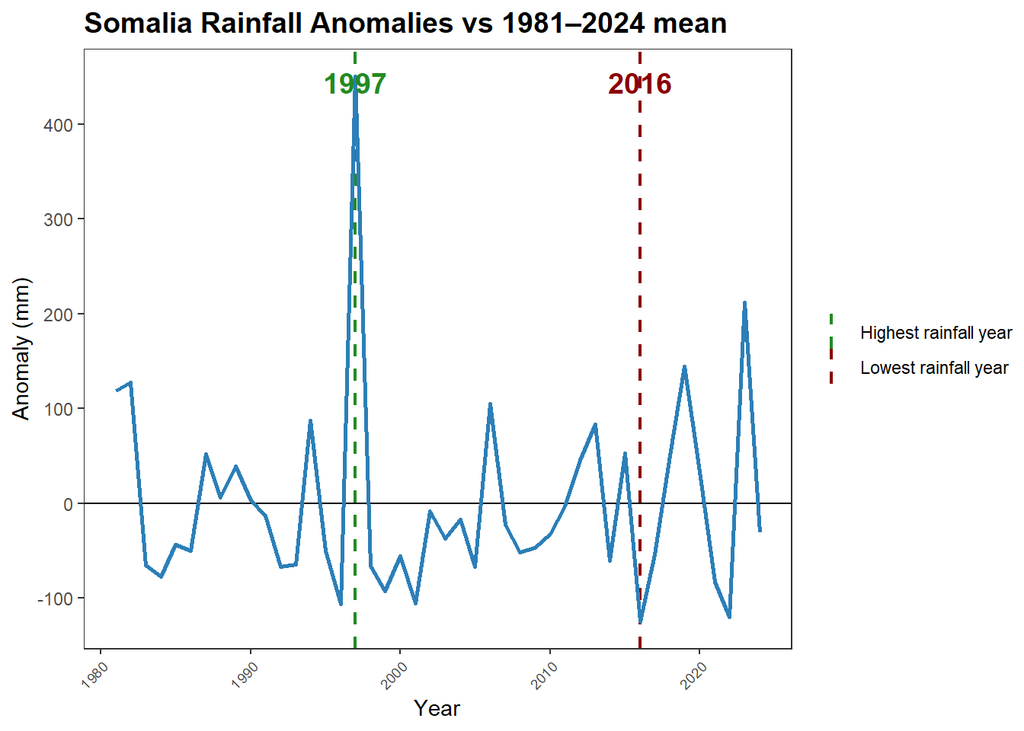

```r
ggplot(som_ts_mean, aes(year, anomaly)) +
  geom_hline(yintercept = 0) +
  geom_vline(
    data = extreme_rainfall_years,
    aes(xintercept = year, color = category),
    linetype = "dashed",
    linewidth = 0.8,
    show.legend = TRUE
  ) +
  geom_line(linewidth = 1, col = "#2C7FB8") +
  geom_text(
    data = extreme_rainfall_years,
    aes(
      x = year,
      y = max(som_ts_mean$anomaly, na.rm = TRUE) * 0.95,
      label = year,
      color = category
    ),
    size = 5,
    fontface = "bold",
    vjust = -0.2,
    show.legend = FALSE
  ) +
  scale_color_manual(values = c(
    "Lowest rainfall year" = "darkred",
    "Highest rainfall year" = "forestgreen"
  )) +
  theme_test() +
  labs(
    title = "Somalia Rainfall Anomalies vs 1981–2024 mean",
    x = "Year",
    y = "Anomaly (mm)",
    color = NULL
  ) +
  theme(
    strip.text = element_text(face = "bold", size = 9),
    plot.title = element_text(face = "bold", size = 14),
    axis.text.x = element_text(angle = 45, hjust = 1, size = 7)
  )
```

```r
# Save CLEAN climate table (national mean + anomaly)
write.csv(
  som_ts_mean,
  file.path("clean_data","climate","somalia_chirps_national_mean_anomaly_1981_2024.csv"),
  row.names = FALSE)
```

## 3.3 Quick EDA summary (Somalia distribution across years)

The annual Somalia-wide mean rainfall series shows pronounced interannual variability, with clear separation between “wet” and “dry” years relative to the long-term mean. In the Wet/Dry classification, several early years were wetter than average (e.g., 1981–1982, 1987–1990), while prolonged dry conditions appear in the early 1990s (1991–1993) and again around the late 1990s to mid-2000s (many years from 1998–2005 classified as dry). Extreme years stand out clearly: 1997 is an exceptional wet outlier (mean ≈ 784 mm; anomaly ≈ +451 mm), whereas 2016 is among the driest years (mean ≈ 209 mm; anomaly ≈ −125 mm). Recent years show mixed conditions, including notable wet years (2019–2020 and 2023) and marked dry years (2021–2022).

**The spatial SD classification adds an important second dimension:** it quantifies whether rainfall in a given year was spatially uneven across Somalia. Years classified as high spatial variability (SD ≥ median) include several wetter-than-average years most notably 1997 (SD ≈ 476 mm), but also 1981, 1982, 1994, 2006, 2018, 2019, and 2023. This indicates that wet years often coincide with strong spatial contrasts, meaning that rainfall increases are not uniform across the country; instead, some areas receive substantially more rainfall than others. Conversely, many years classified as low spatial variability include several drought-like years (e.g., 1996, 2016, 2021–2022), suggesting that in dry years, conditions can be more uniformly dry across Somalia.

Overall, combining both classifications shows that Somalia’s rainfall variability is characterized not only by large year-to-year swings in the national mean, but also by systematic changes in within-country spatial heterogeneity: the wettest years tend to be associated with greater spatial disparity, while many of the driest years show lower spatial variability, consistent with widespread dryness

```r
# Summary per layer (year): mean, sd, min, max across pixels in Somalia
layer_stats <- terra::global(chirps_SOM_terrestrial,
                             fun = c("mean","sd","min","max"),
                             na.rm = TRUE)

layer_stats_df <- tibble(
  year = 1981:2024,
  mean = layer_stats$mean,
  sd   = layer_stats$sd,
  min  = layer_stats$min,
  max  = layer_stats$max
)

knitr::kable(
  layer_stats_df,
  format = "html",
  caption = "Somalia Interannual rainfall Statistics(1981–2024)"
) %>%
  kableExtra::kable_styling(
    full_width = TRUE,
    bootstrap_options = c("striped", "condensed", "hover")
  )
```

Somalia Interannual rainfall Statistics(1981–2024)

| year | mean | sd | min | max |
| --- | --- | --- | --- | --- |
| 1981 | 452.4537 | 283.6399 | 37.0002556 | 1474.2151 |
| 1982 | 461.2739 | 218.5617 | 53.9235687 | 1190.0831 |
| 1983 | 268.8268 | 165.9550 | 27.2139435 | 1036.0292 |
| 1984 | 256.5802 | 164.4955 | 43.3789444 | 951.6064 |
| 1985 | 290.1495 | 197.7998 | 5.5689917 | 861.3688 |
| 1986 | 284.1476 | 155.2058 | 14.7647209 | 1101.4984 |
| 1987 | 385.8816 | 200.8283 | 5.6329808 | 977.8508 |
| 1988 | 340.0360 | 183.8950 | 18.7364883 | 1157.3142 |
| 1989 | 372.7689 | 213.6518 | 13.7225714 | 919.7523 |
| 1990 | 336.8836 | 214.4510 | 21.0027905 | 1039.1593 |
| 1991 | 320.6369 | 193.1396 | 4.9359894 | 1310.0973 |
| 1992 | 266.9518 | 188.1428 | 7.4122338 | 1087.6506 |
| 1993 | 269.3963 | 122.2829 | 9.2637339 | 717.9906 |
| 1994 | 421.3819 | 227.0745 | 46.6038933 | 1146.0996 |
| 1995 | 283.5440 | 161.7650 | 0.0090430 | 945.2786 |
| 1996 | 227.7187 | 116.1843 | 11.4684753 | 977.5212 |
| 1997 | 784.2741 | 476.2907 | 57.9890862 | 2073.8381 |
| 1998 | 267.4935 | 198.5644 | 0.7550910 | 1084.2009 |
| 1999 | 241.2554 | 152.0187 | 0.7479264 | 928.7209 |
| 2000 | 278.2497 | 155.0652 | 2.7358942 | 768.6250 |
| 2001 | 228.2192 | 137.9541 | 4.4710064 | 810.5295 |
| 2002 | 325.3805 | 223.4879 | 19.2745934 | 982.1357 |
| 2003 | 296.2606 | 203.8126 | 2.2214260 | 893.3744 |
| 2004 | 316.7948 | 162.1264 | 37.4302673 | 1013.6902 |
| 2005 | 267.0725 | 136.1136 | 7.0815034 | 1052.5309 |
| 2006 | 438.5315 | 275.4702 | 11.9819984 | 1236.0840 |
| 2007 | 310.8468 | 176.6609 | 18.2437897 | 1110.5208 |
| 2008 | 282.2237 | 175.8485 | 13.7604294 | 1075.9625 |
| 2009 | 287.2044 | 179.4904 | 0.1602321 | 807.4237 |
| 2010 | 301.5432 | 155.3408 | 37.4454956 | 1084.1165 |
| 2011 | 330.3013 | 177.4874 | 6.6819644 | 942.4636 |
| 2012 | 379.6313 | 167.9572 | 29.4238319 | 866.3013 |
| 2013 | 417.3060 | 162.7309 | 36.3430824 | 1003.7191 |
| 2014 | 273.4306 | 139.9095 | 1.9574745 | 910.6882 |
| 2015 | 386.7256 | 219.4896 | 22.7286224 | 949.6476 |
| 2016 | 209.1018 | 118.5852 | 0.1205501 | 747.8890 |
| 2017 | 279.6952 | 167.0895 | 6.5937905 | 825.1909 |
| 2018 | 384.3587 | 234.7334 | 34.0477104 | 1105.0048 |
| 2019 | 478.1282 | 211.2871 | 65.8686218 | 1059.8137 |
| 2020 | 367.1906 | 149.8021 | 56.4521408 | 871.3746 |
| 2021 | 250.9322 | 124.5922 | 28.7578430 | 753.4764 |
| 2022 | 214.1745 | 131.4143 | 0.5800034 | 694.6079 |
| 2023 | 545.3056 | 282.0041 | 16.8581944 | 1392.8298 |
| 2024 | 303.3268 | 146.3341 | 19.4929295 | 909.3373 |

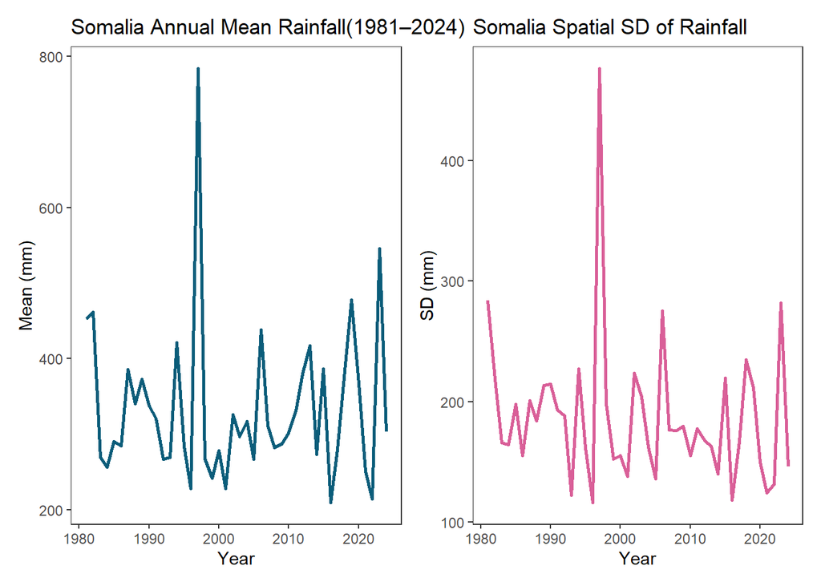

```r
# Plot mean + variability
mean_plot<-ggplot(layer_stats_df, aes(year, mean)) +
  geom_line(linewidth = 1, col="#0B5D7A") +
  theme_test() +
  labs(title="Somalia Annual Mean Rainfall(1981–2024) ", y="Mean (mm)", x="Year")

sd_plot<-ggplot(layer_stats_df, aes(year, sd)) +
  geom_line(linewidth = 1, col="#D95F98") +
  theme_test() +
  labs(title="Somalia Spatial SD of Rainfall", y="SD (mm)", x="Year")

mean_plot|sd_plot
```

# 4 Additional EDA: distribution + summary + extremes

These EDA results show that Somalia’s annual mean rainfall is highly variable across years, but most years cluster in a lower range, with one very extreme wet outlier.

The histogram suggests a right-skewed distribution: many years fall roughly between 250 and 380 mm, while a small number of wet years extend far above this range. The boxplot confirms this and shows that 1997 is a clear upper outlier, meaning it was unusually wet compared with the rest of the 1981–2024 record.

The summary statistics support this pattern. The long-term mean is 333.72 mm, while the median is lower at 302.44 mm, which is another sign of positive skewness caused by a few very wet years. The standard deviation (103.26 mm) is fairly large relative to the mean, indicating strong interannual variability in national rainfall.

The extremes table shows that the driest years were 2016, 2022, 1996, 2001, and 1999, all with strongly negative anomalies. The wettest years were 1997, 2023, 2019, 1982, and 1981, all with positive anomalies, with 1997 standing far above the others. In practical terms, this means Somalia’s rainfall regime is dominated less by a smooth long-term change and more by large year-to-year fluctuations, including occasional extreme wet years and several clustered dry years.

*conclution*: The exploratory analysis indicates that Somalia’s national annual rainfall distribution for 1981–2024 is positively skewed and characterized by substantial interannual variability. Most years cluster around moderate rainfall totals, but a few exceptionally wet years shift the upper tail of the distribution upward. The boxplot identifies 1997 as a strong wet outlier, while the extremes table shows that the driest years are concentrated mainly in the late 1990s, mid-2010s, and early 2020s. Overall, the rainfall series appears to be driven more by year-to-year variability and extreme events than by a stable central pattern.

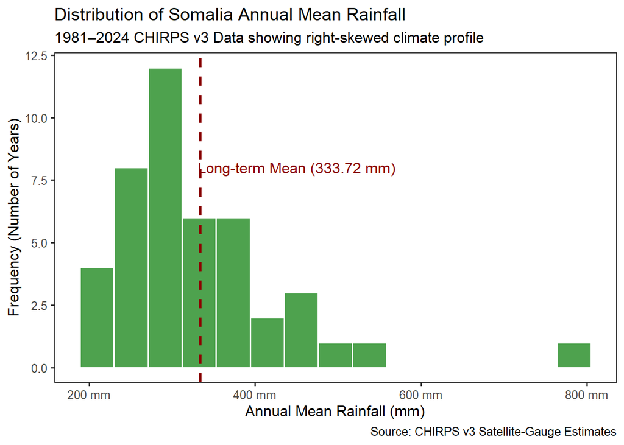

```r
# 1) Distribution check: histogram
ggplot(som_ts_mean, aes(x = mean_rain)) +
  geom_histogram(bins = 15, fill = "forestgreen", color = "white", alpha = 0.8) +
  geom_vline(aes(xintercept = mean(mean_rain)), color = "darkred", linetype = "dashed", size = 1) +
  annotate("text", x = 450, y = 8, label = "Long-term Mean (333.72 mm)", color = "darkred") +
  scale_x_continuous(labels = unit_format(unit = "mm")) +
  labs(
    title = "Distribution of Somalia Annual Mean Rainfall",
    subtitle = "1981–2024 CHIRPS v3 Data showing right-skewed climate profile",
    x = "Annual Mean Rainfall (mm)",
    y = "Frequency (Number of Years)",
    caption = "Source: CHIRPS v3 Satellite-Gauge Estimates"
  ) +
  theme_test(base_size = 12)
```

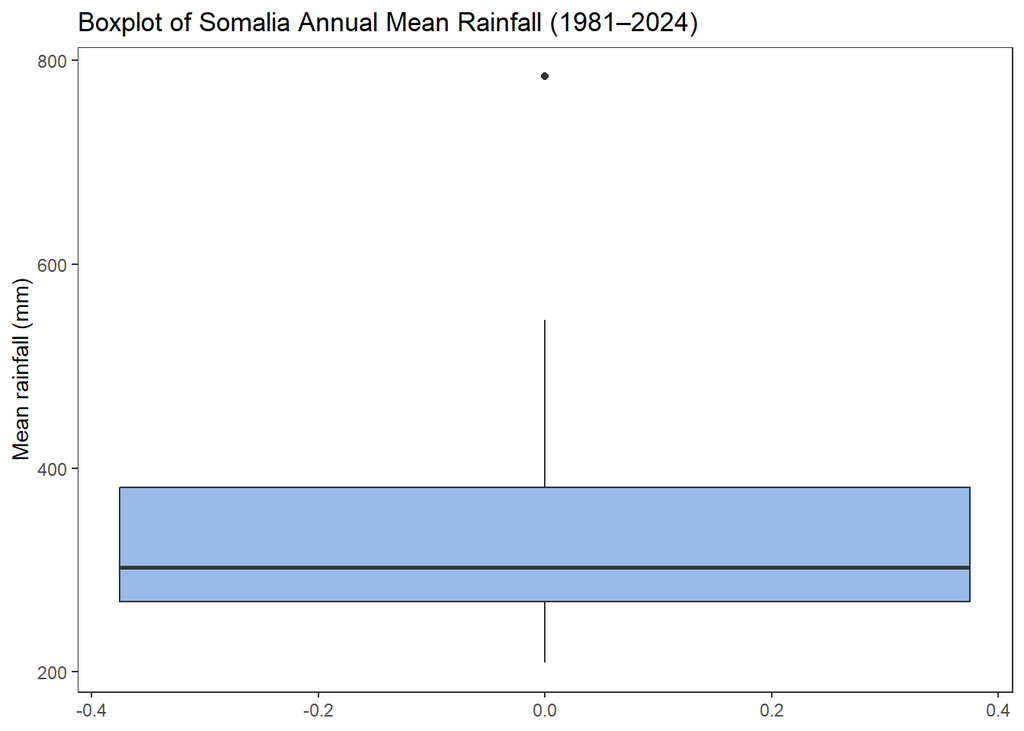

```r
# 2) Distribution check: boxplot
ggplot(som_ts_mean, aes(y = mean_rain)) +
  geom_boxplot(fill = "#99B9E9") +
  theme_test() +
  labs(
    title = "Boxplot of Somalia Annual Mean Rainfall (1981–2024)",
    x = NULL,
    y = "Mean rainfall (mm)"
  )
```

```r
# 3) Summary table
rainfall_summary_table <- som_ts_mean %>%
  summarise(
    observations = n(),
    mean_rainfall_mm = round(mean(mean_rain, na.rm = TRUE), 2),
    sd_rainfall_mm = round(sd(mean_rain, na.rm = TRUE), 2),
    min_rainfall_mm = round(min(mean_rain, na.rm = TRUE), 2),
    median_rainfall_mm = round(median(mean_rain, na.rm = TRUE), 2),
    max_rainfall_mm = round(max(mean_rain, na.rm = TRUE), 2)
  )

knitr::kable(
  rainfall_summary_table,
  format = "html",
  caption = "Summary Statistics for Somalia National Annual Mean Rainfall (CHIRPS v3), 1981–2024"
) %>%
  kableExtra::kable_styling(
    full_width = TRUE,
    bootstrap_options = c("striped", "condensed", "hover")
  )
```

Summary Statistics for Somalia National Annual Mean Rainfall (CHIRPS v3), 1981–2024

| observations | mean_rainfall_mm | sd_rainfall_mm | min_rainfall_mm | median_rainfall_mm | max_rainfall_mm |
| --- | --- | --- | --- | --- | --- |
| 44 | 333.72 | 103.26 | 209.1 | 302.44 | 784.27 |

```r
# 4) Extremes table
rainfall_extremes_table <- bind_rows(
  som_ts_mean %>%
    arrange(mean_rain) %>%
    slice(1:5) %>%
    mutate(category = "Lowest rainfall years"),
  som_ts_mean %>%
    arrange(desc(mean_rain)) %>%
    slice(1:5) %>%
    mutate(category = "Highest rainfall years")
) %>%
  select(category, year, mean_rain, anomaly)

knitr::kable(
  rainfall_extremes_table %>%
    mutate(
      mean_rain = round(mean_rain, 2),
      anomaly = round(anomaly, 2)
    ),
  format = "html",
  caption = "Lowest and Highest Rainfall Years in Somalia (CHIRPS v3), 1981–2024"
) %>%
  kableExtra::kable_styling(
    full_width = TRUE,
    bootstrap_options = c("striped", "condensed", "hover")
  )
```

Lowest and Highest Rainfall Years in Somalia (CHIRPS v3), 1981–2024

| category | year | mean_rain | anomaly |
| --- | --- | --- | --- |
| Lowest rainfall years | 2016 | 209.10 | -124.62 |
| Lowest rainfall years | 2022 | 214.17 | -119.54 |
| Lowest rainfall years | 1996 | 227.72 | -106.00 |
| Lowest rainfall years | 2001 | 228.22 | -105.50 |
| Lowest rainfall years | 1999 | 241.26 | -92.46 |
| Highest rainfall years | 1997 | 784.27 | 450.56 |
| Highest rainfall years | 2023 | 545.31 | 211.59 |
| Highest rainfall years | 2019 | 478.13 | 144.41 |
| Highest rainfall years | 1982 | 461.27 | 127.56 |
| Highest rainfall years | 1981 | 452.45 | 118.74 |

## 4.1 High vs Low Spatial Variability Classification (within-Somalia SD)

This step measures whether rainfall in a given year was spatially uniform or spatially heterogeneous across Somalia. For each year, you compute the spatial `SD` of rainfall across Somalia land pixels. You then classify the year as High spatial variability if `SD ≥` the median `SD` across 1981–2024, otherwise Low spatial variability. The Threshold_Definition column documents this rule.

*Results*: Years with the highest `SD` (like 1997 at the top of the ranking) indicate rainfall was very uneven across Somalia—some areas received much more rainfall than others. Several other high-SD years (including some wet years) suggest that high national rainfall can coincide with strong geographic contrasts rather than uniform wetting. In contrast, `low-SD` years reflect more spatially consistent conditions (often widespread dryness or broadly similar rainfall patterns). This classification complements the Wet/Dry anomaly analysis by separating how wet/dry the year was nationally from how evenly rainfall was distributed spatially across the country

```r
sd_cut <- median(layer_stats_df$sd, na.rm = TRUE)

years_variability_table <- layer_stats_df %>%
  mutate(
   Spatial_Variability = ifelse(sd >= sd_cut, "High spatial variability", "Low spatial variability"),
    Threshold_Definition = ifelse(sd >= sd_cut, ">= median SD", "< median SD")
  ) %>%
  select(year, mean, sd, Spatial_Variability,Threshold_Definition ) %>%
  arrange(desc(sd)) %>%
  mutate(across(c(mean, sd), ~round(.x, 2)))

knitr::kable(
  years_variability_table,
  format = "html",
  caption = "Somalia Years Classified into Two Groups by Spatial Variability (SD), 1981–2024"
) %>%
  kableExtra::kable_styling(
    full_width = TRUE,
    bootstrap_options = c("striped", "condensed", "hover")
  )
```

Somalia Years Classified into Two Groups by Spatial Variability (SD), 1981–2024

| year | mean | sd | Spatial_Variability | Threshold_Definition |
| --- | --- | --- | --- | --- |
| 1997 | 784.27 | 476.29 | High spatial variability | >= median SD |
| 1981 | 452.45 | 283.64 | High spatial variability | >= median SD |
| 2023 | 545.31 | 282.00 | High spatial variability | >= median SD |
| 2006 | 438.53 | 275.47 | High spatial variability | >= median SD |
| 2018 | 384.36 | 234.73 | High spatial variability | >= median SD |
| 1994 | 421.38 | 227.07 | High spatial variability | >= median SD |
| 2002 | 325.38 | 223.49 | High spatial variability | >= median SD |
| 2015 | 386.73 | 219.49 | High spatial variability | >= median SD |
| 1982 | 461.27 | 218.56 | High spatial variability | >= median SD |
| 1990 | 336.88 | 214.45 | High spatial variability | >= median SD |
| 1989 | 372.77 | 213.65 | High spatial variability | >= median SD |
| 2019 | 478.13 | 211.29 | High spatial variability | >= median SD |
| 2003 | 296.26 | 203.81 | High spatial variability | >= median SD |
| 1987 | 385.88 | 200.83 | High spatial variability | >= median SD |
| 1998 | 267.49 | 198.56 | High spatial variability | >= median SD |
| 1985 | 290.15 | 197.80 | High spatial variability | >= median SD |
| 1991 | 320.64 | 193.14 | High spatial variability | >= median SD |
| 1992 | 266.95 | 188.14 | High spatial variability | >= median SD |
| 1988 | 340.04 | 183.89 | High spatial variability | >= median SD |
| 2009 | 287.20 | 179.49 | High spatial variability | >= median SD |
| 2011 | 330.30 | 177.49 | High spatial variability | >= median SD |
| 2007 | 310.85 | 176.66 | High spatial variability | >= median SD |
| 2008 | 282.22 | 175.85 | Low spatial variability | < median SD |
| 2012 | 379.63 | 167.96 | Low spatial variability | < median SD |
| 2017 | 279.70 | 167.09 | Low spatial variability | < median SD |
| 1983 | 268.83 | 165.95 | Low spatial variability | < median SD |
| 1984 | 256.58 | 164.50 | Low spatial variability | < median SD |
| 2013 | 417.31 | 162.73 | Low spatial variability | < median SD |
| 2004 | 316.79 | 162.13 | Low spatial variability | < median SD |
| 1995 | 283.54 | 161.76 | Low spatial variability | < median SD |
| 2010 | 301.54 | 155.34 | Low spatial variability | < median SD |
| 1986 | 284.15 | 155.21 | Low spatial variability | < median SD |
| 2000 | 278.25 | 155.07 | Low spatial variability | < median SD |
| 1999 | 241.26 | 152.02 | Low spatial variability | < median SD |
| 2020 | 367.19 | 149.80 | Low spatial variability | < median SD |
| 2024 | 303.33 | 146.33 | Low spatial variability | < median SD |
| 2014 | 273.43 | 139.91 | Low spatial variability | < median SD |
| 2001 | 228.22 | 137.95 | Low spatial variability | < median SD |
| 2005 | 267.07 | 136.11 | Low spatial variability | < median SD |
| 2022 | 214.17 | 131.41 | Low spatial variability | < median SD |
| 2021 | 250.93 | 124.59 | Low spatial variability | < median SD |
| 1993 | 269.40 | 122.28 | Low spatial variability | < median SD |
| 2016 | 209.10 | 118.59 | Low spatial variability | < median SD |
| 1996 | 227.72 | 116.18 | Low spatial variability | < median SD |

## 4.2 Wet vs Dry Year Classification (relative to 1981–2024 mean)

*Results*: The classification shows frequent switching between Wet and Dry years, confirming strong interannual variability. Extreme conditions are clearly separated: 1997 is an exceptionally Wet year (very large positive anomaly), while 2016 is among the driest years (largest negative anomaly). Periods such as the early 1990s and late 1990s–early 2000s contain multiple Dry years, while recent years show sharp swings, including strongly Wet years (e.g., 2019, 2023) and strongly Dry years (e.g., 2021–2022). Overall, the Wet/Dry grouping provides an interpretable summary of national departures from the climatological baseline.

```r
## Wet vs Dry Year Classification (relative to 1981–2024 mean)

# 1. Create the classification table
years_class_table <- layer_stats_df %>%
  mutate(
    anomaly = mean - mean(mean, na.rm = TRUE),
    Rainfall_Class = ifelse(anomaly >= 0, "Wet", "Dry"),
    Threshold_Definition = ifelse(anomaly >= 0, ">= long-term mean", "< long-term mean")
  ) %>%
  select(year, mean, anomaly, Rainfall_Class, Threshold_Definition) %>%
  arrange(year) %>%
  mutate(across(c(mean, anomaly), ~round(.x, 2)))

# 2. Display the table
knitr::kable(
  years_class_table,
  format = "html",
  caption = "Somalia Annual Rainfall Years Classified into Two Groups (Wet vs Dry), 1981–2024"
) %>%
  kableExtra::kable_styling(
    full_width = TRUE,
    bootstrap_options = c("striped", "condensed", "hover")
  )
```

Somalia Annual Rainfall Years Classified into Two Groups (Wet vs Dry), 1981–2024

| year | mean | anomaly | Rainfall_Class | Threshold_Definition |
| --- | --- | --- | --- | --- |
| 1981 | 452.45 | 118.74 | Wet | >= long-term mean |
| 1982 | 461.27 | 127.56 | Wet | >= long-term mean |
| 1983 | 268.83 | -64.89 | Dry | < long-term mean |
| 1984 | 256.58 | -77.14 | Dry | < long-term mean |
| 1985 | 290.15 | -43.57 | Dry | < long-term mean |
| 1986 | 284.15 | -49.57 | Dry | < long-term mean |
| 1987 | 385.88 | 52.16 | Wet | >= long-term mean |
| 1988 | 340.04 | 6.32 | Wet | >= long-term mean |
| 1989 | 372.77 | 39.05 | Wet | >= long-term mean |
| 1990 | 336.88 | 3.17 | Wet | >= long-term mean |
| 1991 | 320.64 | -13.08 | Dry | < long-term mean |
| 1992 | 266.95 | -66.77 | Dry | < long-term mean |
| 1993 | 269.40 | -64.32 | Dry | < long-term mean |
| 1994 | 421.38 | 87.66 | Wet | >= long-term mean |
| 1995 | 283.54 | -50.17 | Dry | < long-term mean |
| 1996 | 227.72 | -106.00 | Dry | < long-term mean |
| 1997 | 784.27 | 450.56 | Wet | >= long-term mean |
| 1998 | 267.49 | -66.22 | Dry | < long-term mean |
| 1999 | 241.26 | -92.46 | Dry | < long-term mean |
| 2000 | 278.25 | -55.47 | Dry | < long-term mean |
| 2001 | 228.22 | -105.50 | Dry | < long-term mean |
| 2002 | 325.38 | -8.34 | Dry | < long-term mean |
| 2003 | 296.26 | -37.46 | Dry | < long-term mean |
| 2004 | 316.79 | -16.92 | Dry | < long-term mean |
| 2005 | 267.07 | -66.65 | Dry | < long-term mean |
| 2006 | 438.53 | 104.81 | Wet | >= long-term mean |
| 2007 | 310.85 | -22.87 | Dry | < long-term mean |
| 2008 | 282.22 | -51.49 | Dry | < long-term mean |
| 2009 | 287.20 | -46.51 | Dry | < long-term mean |
| 2010 | 301.54 | -32.17 | Dry | < long-term mean |
| 2011 | 330.30 | -3.42 | Dry | < long-term mean |
| 2012 | 379.63 | 45.91 | Wet | >= long-term mean |
| 2013 | 417.31 | 83.59 | Wet | >= long-term mean |
| 2014 | 273.43 | -60.29 | Dry | < long-term mean |
| 2015 | 386.73 | 53.01 | Wet | >= long-term mean |
| 2016 | 209.10 | -124.62 | Dry | < long-term mean |
| 2017 | 279.70 | -54.02 | Dry | < long-term mean |
| 2018 | 384.36 | 50.64 | Wet | >= long-term mean |
| 2019 | 478.13 | 144.41 | Wet | >= long-term mean |
| 2020 | 367.19 | 33.47 | Wet | >= long-term mean |
| 2021 | 250.93 | -82.79 | Dry | < long-term mean |
| 2022 | 214.17 | -119.54 | Dry | < long-term mean |
| 2023 | 545.31 | 211.59 | Wet | >= long-term mean |
| 2024 | 303.33 | -30.39 | Dry | < long-term mean |

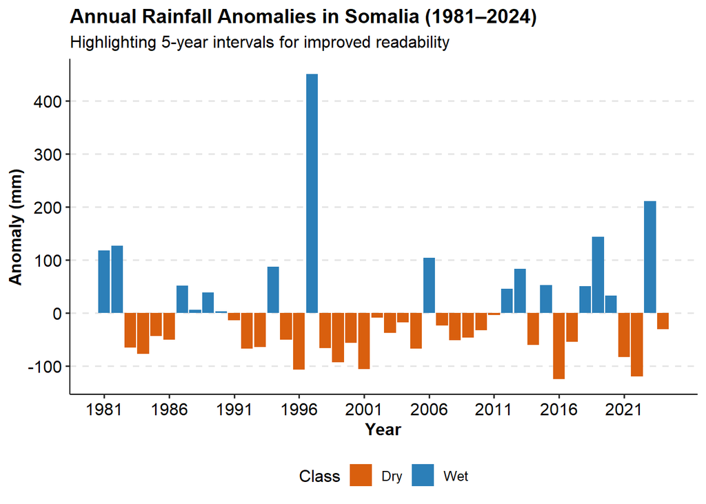

```r
# 3. Plot with 5-year breaks
ggplot(years_class_table, aes(x = year, y = anomaly, fill = Rainfall_Class)) +
  geom_col() +
  scale_fill_manual(values = c("Wet" = "#2C7FB8", "Dry" = "#D95F0E")) +
  # Use scale_x_continuous instead of factor(year) to allow for numeric breaks
  scale_x_continuous(breaks = seq(1981, 2024, by = 5)) +
  labs(
    title = "Annual Rainfall Anomalies in Somalia (1981–2024)",
    subtitle = "Highlighting 5-year intervals for improved readability",
    x = "Year",
    y = "Anomaly (mm)",
    fill = "Class"
  ) +
  theme_pubr() +
  theme(
    legend.position = "bottom",
    plot.title = element_text(face = "bold", size = 14),
    axis.title = element_text(face = "bold"),
    panel.grid.major.y = element_line(color = "grey90", linetype = "dashed") # subtle horizontal guides
  )
```

## 4.3 OLS Linear Trend Analysis of National Rainfall

Using annual, country‐mean CHIRPS v3 rainfall for Somalia (1981–2024), we fit an ordinary least squares model: *mean_raint=β0+β1t+εt*.

The estimated linear trend is β₁ = −0.0768 mm·yr⁻¹ (SE = 1.240), indicating an extremely small decrease. Scaled over the 44-year record, this corresponds to an expected change of approximately −3.4 mm, which is negligible relative to the observed interannual variability (residual SD ≈ 104.5 mm).

Statistical evidence for a monotonic trend is absent: t(42) = −0.062, p = 0.951 for β₁. The model explains essentially none of the variance in annual mean rainfall (R² = 9.1×10⁻⁵; adjusted R² = −0.0237), consistent with rainfall variability being dominated by year-to-year fluctuations rather than a detectable linear change both increase or decrease over the study period in the CHIRPS series.

```r
fit <- lm(mean_rain ~ year, data = som_ts_mean)
summary(fit)
```

```
##
## Call:
## lm(formula = mean_rain ~ year, data = som_ts_mean)
##
## Residuals:
##     Min      1Q  Median      3Q     Max
## -123.58  -65.39  -30.17   47.73  450.13
##
## Coefficients:
##               Estimate Std. Error t value Pr(>|t|)
## (Intercept)  487.46184 2483.77782   0.196    0.845
## year          -0.07678    1.24031  -0.062    0.951
##
## Residual standard error: 104.5 on 42 degrees of freedom
## Multiple R-squared:  9.122e-05,  Adjusted R-squared:  -0.02372
## F-statistic: 0.003832 on 1 and 42 DF,  p-value: 0.9509
```

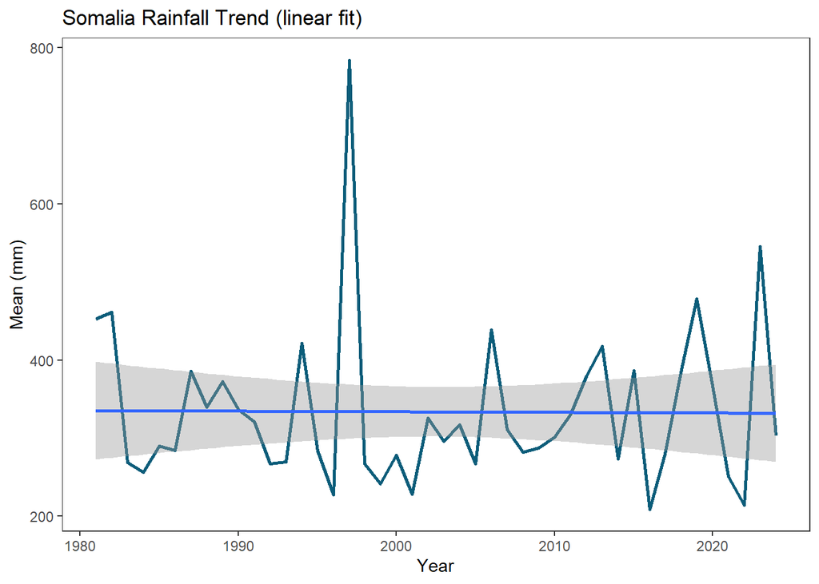

```r
ggplot(som_ts_mean, aes(year, mean_rain)) +
  geom_line(linewidth = 1, col="#0B5D7A") +
  geom_smooth(method = "lm", se = TRUE) +
  theme_test() +
  labs(title="Somalia Rainfall Trend (linear fit)", x="Year", y="Mean (mm)")
```

## 4.4 National Monotonic Trend in Mean Rainfall (1981–2024; MK + Sen)

This section tests whether Somalia’s national annual mean rainfall exhibits a monotonic long-term change over 1981–2024. We use the Mann–Kendall rank test to evaluate trend significance and Sen’s slope to estimate a robust trend magnitude. These non-parametric methods are widely used in hydro-climate trend detection because they do not require normality and are less sensitive to extreme wet/dry years than OLS-based inference.

*Results*: At the national scale, there is no evidence of a monotonic rainfall trend over 1981–2024 (Mann–Kendall τ ≈ 0.002, p ≈ 0.992). Sen’s slope is near zero (≈ 0.020 mm·yr⁻¹; 95% CI ≈ −1.983 to 1.943 mm·yr⁻¹), indicating negligible long-term change relative to interannual variability.

```r
## National rainfall trend (Somalia, CHIRPS v3, 1981–2024): Mann–Kendall + Sen slope

# Mann–Kendall trend test (non-parametric)
mk_nat  <- Kendall::MannKendall(som_ts_mean$mean_rain)

# Sen slope (robust slope estimate + 95% CI)
sen_nat <- trend::sens.slope(som_ts_mean$mean_rain)

cat("Mann–Kendall τ statistic:", mk_nat$tau, " | p-value:", mk_nat$sl, "\n")
```

```
## Mann–Kendall τ statistic: 0.002114165  | p-value: 0.9919301
```

```r
cat("Sen’s slope estimate (mm/year):", sen_nat$estimates,
    " | 95% CI bounds:", sen_nat$conf.int, "\n")
```

```
## Sen’s slope estimate (mm/year): 0.01971338  | 95% CI bounds: -1.982677 1.943078
```

## 4.5 Regional Annual Mean Rainfall Time Series (1981-2024)

```r
## Regional mean rainfall  time series Plot (18 regions, 1981–2024)
region_ts_mean <- exactextractr::exact_extract(
  chirps_SOM_terrestrial, somalia_regions, "mean")
```

[output not shown]

```r
region_ts_mean <- tibble(
  Region = somalia_regions$NAME_1,
  region_ts_mean)
names(region_ts_mean)[-1] <- 1981:2024
region_ts_mean <- region_ts_mean %>%
  pivot_longer(
    cols = -Region,
    names_to = "year",
    values_to = "mean_rain"
  ) %>%
  mutate(year = as.integer(year))

datatable(
  region_ts_mean,
  rownames = FALSE,
  caption = "Somalia regional mean annual rainfall (CHIRPS v3), 1981–2024)"
) %>%
  formatRound("mean_rain", 2)
```

| Region | year | mean_rain |
| --- | --- | --- |
| Awdal | 1981 | 453.4049072265625 |
| Awdal | 1982 | 507.7401123046875 |
| Awdal | 1983 | 391.3206481933594 |
| Awdal | 1984 | 235.4842224121094 |
| Awdal | 1985 | 235.6894226074219 |
| Awdal | 1986 | 286.3702697753906 |
| Awdal | 1987 | 273.3363342285156 |
| Awdal | 1988 | 211.853515625 |
| Awdal | 1989 | 339.8279724121094 |
| Awdal | 1990 | 241.5322723388672 |

[output cut: 782 more lines]

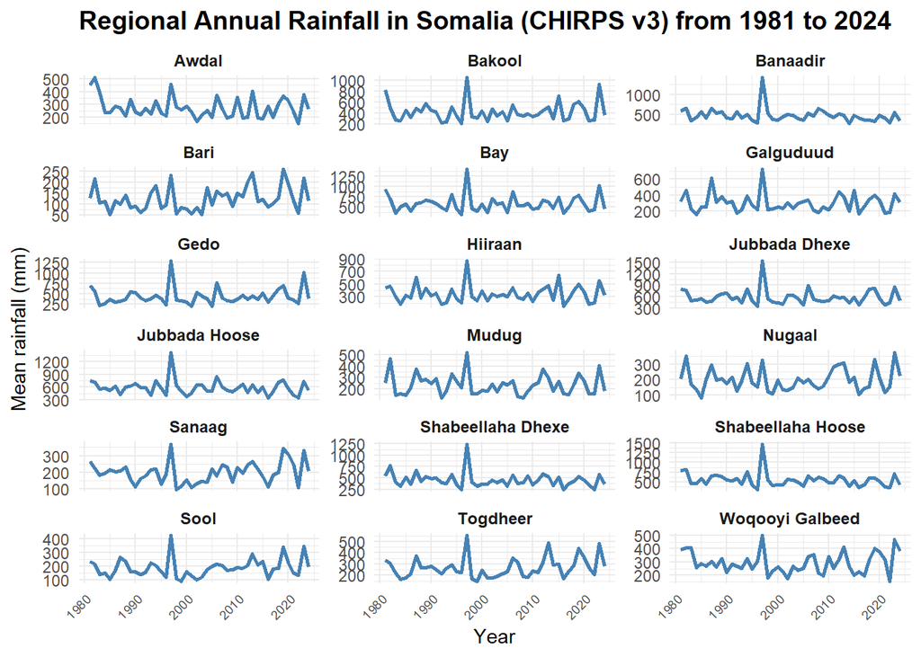

```r
# Plot the 18 region mean rainfall

ggplot(region_ts_mean, aes(year, mean_rain)) +
  geom_line(linewidth = 1, col = "steelblue") +
  facet_wrap(~Region, scales = "free_y", ncol = 3) +
  theme_minimal() +
  labs(
    title = "Regional Annual Rainfall in Somalia (CHIRPS v3) from 1981 to 2024",
    x = "Year",
    y = "Mean rainfall (mm)"
  ) +
  theme(
    strip.text = element_text(face = "bold", size = 9),
    plot.title = element_text(face = "bold", size = 14),
    axis.text.x = element_text(angle = 45, hjust = 1, size = 7)
  )
```

```r
write.csv(region_ts_mean,
          file.path("clean_data","climate","somalia_chirps_regional_mean_1981_2024.csv"),
          row.names = FALSE)
```

# 5 Regional Rainfall Statistics (1981–2024)

```r
# Summary per region across years: mean, sd, min, max
region_stats <- region_ts_mean %>%
  group_by(Region) %>%
  summarise(
    mean = mean(mean_rain, na.rm = TRUE),
    sd   = sd(mean_rain, na.rm = TRUE),
    min  = min(mean_rain, na.rm = TRUE),
    max  = max(mean_rain, na.rm = TRUE),
    .groups = "drop"
  ) %>%
  arrange(desc(mean)) %>%
  mutate(across(c(mean, sd, min, max), round, 2))

knitr::kable(
  region_stats,
  format = "html",
  caption = "Regional Rainfall Statistics in Somalia (1981–2024)"
) %>%
  kableExtra::kable_styling(
    full_width = TRUE,
    bootstrap_options = c("striped", "condensed", "hover")
  )
```

Regional Rainfall Statistics in Somalia (1981–2024)

| Region | mean | sd | min | max |
| --- | --- | --- | --- | --- |
| Jubbada Hoose | 591.97 | 172.00 | 350.00 | 1410.50 |
| Jubbada Dhexe | 585.44 | 199.40 | 347.26 | 1534.07 |
| Bay | 581.72 | 204.76 | 310.02 | 1415.69 |
| Shabeellaha Hoose | 556.75 | 184.48 | 313.46 | 1468.13 |
| Banaadir | 471.38 | 175.99 | 275.72 | 1417.88 |
| Shabeellaha Dhexe | 456.75 | 164.90 | 248.71 | 1244.52 |
| Gedo | 441.32 | 203.54 | 203.94 | 1287.23 |
| Bakool | 425.61 | 182.20 | 212.64 | 1048.27 |
| Hiiraan | 349.05 | 137.84 | 151.31 | 865.62 |
| Galguduud | 300.06 | 114.91 | 153.10 | 720.18 |
| Woqooyi Galbeed | 294.01 | 79.29 | 158.16 | 498.10 |
| Awdal | 275.35 | 82.81 | 153.76 | 507.74 |
| Togdheer | 270.04 | 90.28 | 150.76 | 552.20 |
| Mudug | 236.33 | 90.77 | 121.19 | 518.74 |
| Sanaag | 198.68 | 63.98 | 96.66 | 370.15 |
| Nugaal | 198.44 | 70.79 | 83.35 | 373.62 |
| Sool | 190.14 | 66.70 | 94.59 | 421.66 |
| Bari | 125.00 | 54.84 | 51.67 | 259.12 |

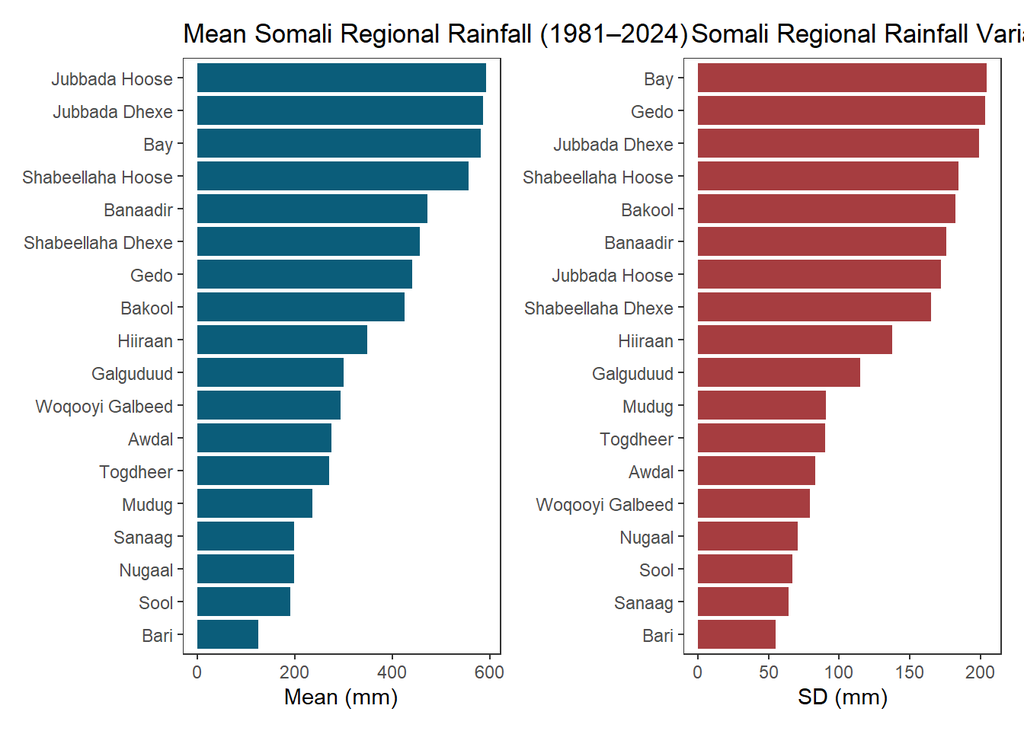

```r
# Plot mean + variability across regions
mean_plot <- ggplot(region_stats, aes(reorder(Region, mean), mean)) +
  geom_col(fill = "#0B5D7A") +
  coord_flip() +
  theme_test() +
  labs(
    title = "Mean Somali Regional Rainfall (1981–2024)",
    x = NULL, y = "Mean (mm)"
  )

sd_plot <- ggplot(region_stats, aes(reorder(Region, sd), sd)) +
  geom_col(fill = "#A63D40") +
  coord_flip() +
  theme_test() +
  labs(
    title = " Somali Regional Rainfall Variability (1981–2024)",
    x = NULL, y = "SD (mm)"
  )

mean_plot | sd_plot
```

## 5.1 Regional Rainfall Anomalies in Somalia Heatmap (1981–2024)

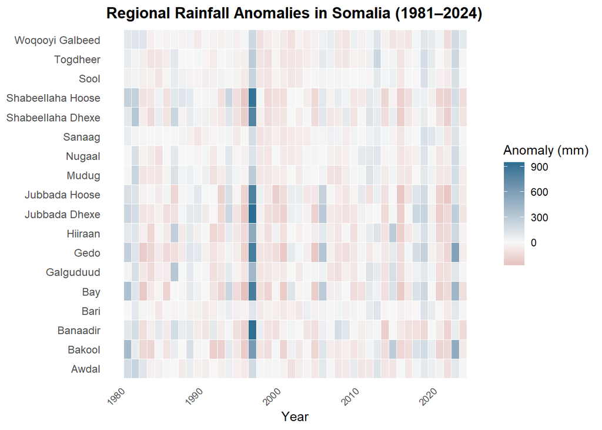

```r
region_ts_mean <- region_ts_mean %>%
  group_by(Region) %>%
  mutate(
    anomaly = mean_rain - mean(mean_rain, na.rm = TRUE)
  ) %>%
  ungroup()

ggplot(region_ts_mean, aes(year, Region, fill = anomaly)) +
  geom_tile(color = "white", linewidth = 0.15) +
  scale_fill_gradient2(
    low = "#A63D40",
    mid = "#F7F7F7",
    high = "#2C6E91",
    midpoint = 0,
    name = "Anomaly (mm)"
  ) +
  theme_minimal() +
  labs(
    title = "Regional Rainfall Anomalies in Somalia (1981–2024)",
    x = "Year",
    y = NULL
  ) +
  theme(
    axis.text.y = element_text(size = 9),
    axis.text.x = element_text(angle = 45, hjust = 1, size = 8),
    plot.title = element_text(face = "bold", size = 13),
    panel.grid = element_blank()
  )
```

## 5.2 Regional Spatial Distribution and classification of Long-Term Mean Rainfall (1981–2024 Map)

*Results:* The 1981–2024 CHIRPS climatology reveals strong spatial heterogeneity in Somalia’s rainfall. The highest long-term regional means occur in the southern regions specillay (Jubbada Hoose, Jubbada Dhexe, Bay, and Shabeellaha Hoose; ~557–592 mm), while the lowest means occur in the northeast and east (Bari ~125 mm; Sool, Nugaal, Sanaag ~190–199 mm).

```r
# Long-term mean rainfall by region from the regional time series
regions_mean_table <- region_ts_mean %>%
  group_by(Region) %>%
  summarise(
    Mean_Rainfall_mm_1981_2024 = round(mean(mean_rain, na.rm = TRUE), 2),
    SD_Rainfall = round(sd(mean_rain, na.rm = TRUE), 2),
    .groups = "drop"
  ) %>%
  mutate(
    Rainfall_Class = case_when(
      Mean_Rainfall_mm_1981_2024 >= 500 ~ "Very wet",
      Mean_Rainfall_mm_1981_2024 >= 400 ~ "Moderately wet",
      Mean_Rainfall_mm_1981_2024 >= 250 ~ "Semi-arid",
      TRUE                              ~ "Arid"
    ),
    Threshold_Definition = case_when(
      Mean_Rainfall_mm_1981_2024 >= 500 ~ ">= 500 mm",
      Mean_Rainfall_mm_1981_2024 >= 400 ~ "400–499 mm",
      Mean_Rainfall_mm_1981_2024 >= 250 ~ "250–399 mm",
      TRUE                              ~ "< 250 mm"
    )
  ) %>%
  arrange(desc(Mean_Rainfall_mm_1981_2024))

knitr::kable(
  regions_mean_table,
  format = "html",
  caption = "Somalia Regions Classified by Mean Annual Rainfall (CHIRPS v3, 1981–2024)"
) %>%
  kableExtra::kable_styling(
    full_width = TRUE,
    bootstrap_options = c("striped", "condensed", "hover")
  )
```

Somalia Regions Classified by Mean Annual Rainfall (CHIRPS v3, 1981–2024)

| Region | Mean_Rainfall_mm_1981_2024 | SD_Rainfall | Rainfall_Class | Threshold_Definition |
| --- | --- | --- | --- | --- |
| Jubbada Hoose | 591.97 | 172.00 | Very wet | >= 500 mm |
| Jubbada Dhexe | 585.44 | 199.40 | Very wet | >= 500 mm |
| Bay | 581.72 | 204.76 | Very wet | >= 500 mm |
| Shabeellaha Hoose | 556.75 | 184.48 | Very wet | >= 500 mm |
| Banaadir | 471.38 | 175.99 | Moderately wet | 400–499 mm |
| Shabeellaha Dhexe | 456.75 | 164.90 | Moderately wet | 400–499 mm |
| Gedo | 441.32 | 203.54 | Moderately wet | 400–499 mm |
| Bakool | 425.61 | 182.20 | Moderately wet | 400–499 mm |
| Hiiraan | 349.05 | 137.84 | Semi-arid | 250–399 mm |
| Galguduud | 300.06 | 114.91 | Semi-arid | 250–399 mm |
| Woqooyi Galbeed | 294.01 | 79.29 | Semi-arid | 250–399 mm |
| Awdal | 275.35 | 82.81 | Semi-arid | 250–399 mm |
| Togdheer | 270.04 | 90.28 | Semi-arid | 250–399 mm |
| Mudug | 236.33 | 90.77 | Arid | < 250 mm |
| Sanaag | 198.68 | 63.98 | Arid | < 250 mm |
| Nugaal | 198.44 | 70.79 | Arid | < 250 mm |
| Sool | 190.14 | 66.70 | Arid | < 250 mm |
| Bari | 125.00 | 54.84 | Arid | < 250 mm |

## 5.3 Heat Map for the Regional Rainfall classification in Somalia (1981-2024)

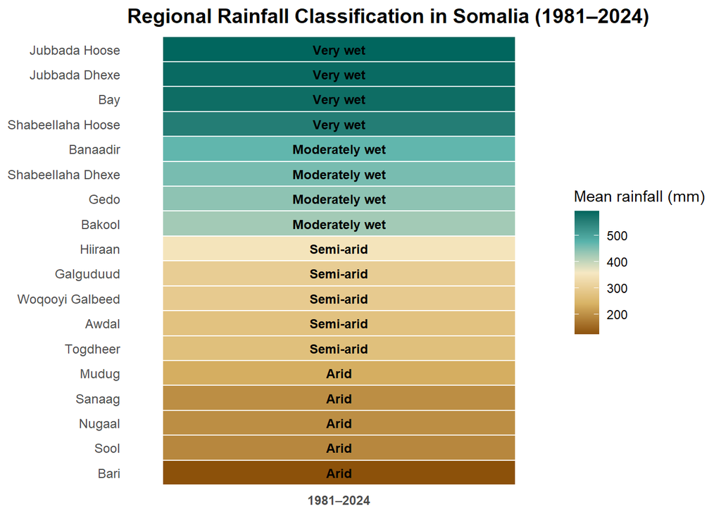

```r
ggplot(
  regions_mean_table,
  aes(x = "1981–2024", y = reorder(Region, Mean_Rainfall_mm_1981_2024), fill = Mean_Rainfall_mm_1981_2024)
) +
  geom_tile(color = "white", linewidth = 0.5) +
  geom_text(aes(label = Rainfall_Class), size = 3.2, color = "black", fontface = "bold") +
  scale_fill_gradientn(
    colours = c("#8C510A", "#D8B365", "#F6E8C3", "#5AB4AC", "#01665E"),
    name = "Mean rainfall (mm)"
  ) +
  theme_minimal() +
  labs(
    title = "Regional Rainfall Classification in Somalia (1981–2024)",
    x = NULL,
    y = NULL
  ) +
  theme(
    plot.title = element_text(face = "bold", size = 14),
    axis.text.x = element_text(face = "bold"),
    axis.text.y = element_text(size = 9),
    panel.grid = element_blank()
  )
```

### 5.3.1 Regional Differences: Wettest vs Driest Regions

```r
# Identify wettest and driest regions from regions_mean_table
hi_name <- regions_mean_table$Region[which.max(regions_mean_table$Mean_Rainfall_mm_1981_2024)]
lo_name <- regions_mean_table$Region[which.min(regions_mean_table$Mean_Rainfall_mm_1981_2024)]

somalia_regions$hi_lo <- ifelse(
  somalia_regions$NAME_1 == hi_name, "Highest mean rainfall",
  ifelse(somalia_regions$NAME_1 == lo_name, "Lowest mean rainfall", "Other")
)

somalia_regions %>%
  st_drop_geometry() %>%
  filter(hi_lo != "Other") %>%
  select(Region = NAME_1, hi_lo) %>%
  left_join(
    regions_mean_table %>%
      select(Region, Mean_Rainfall_mm_1981_2024),
    by = "Region"
  ) %>%
  knitr::kable(
    format = "html",
    caption = "Wettest and driest regions in Somalia based on mean annual rainfall (1981–2024)"
  ) %>%
  kableExtra::kable_styling(
    full_width = FALSE,
    bootstrap_options = c("striped", "condensed", "hover")
  )
```

Wettest and driest regions in Somalia based on mean annual rainfall (1981–2024)

| Region | hi_lo | Mean_Rainfall_mm_1981_2024 |
| --- | --- | --- |
| Bari | Lowest mean rainfall | 125.00 |
| Jubbada Hoose | Highest mean rainfall | 591.97 |

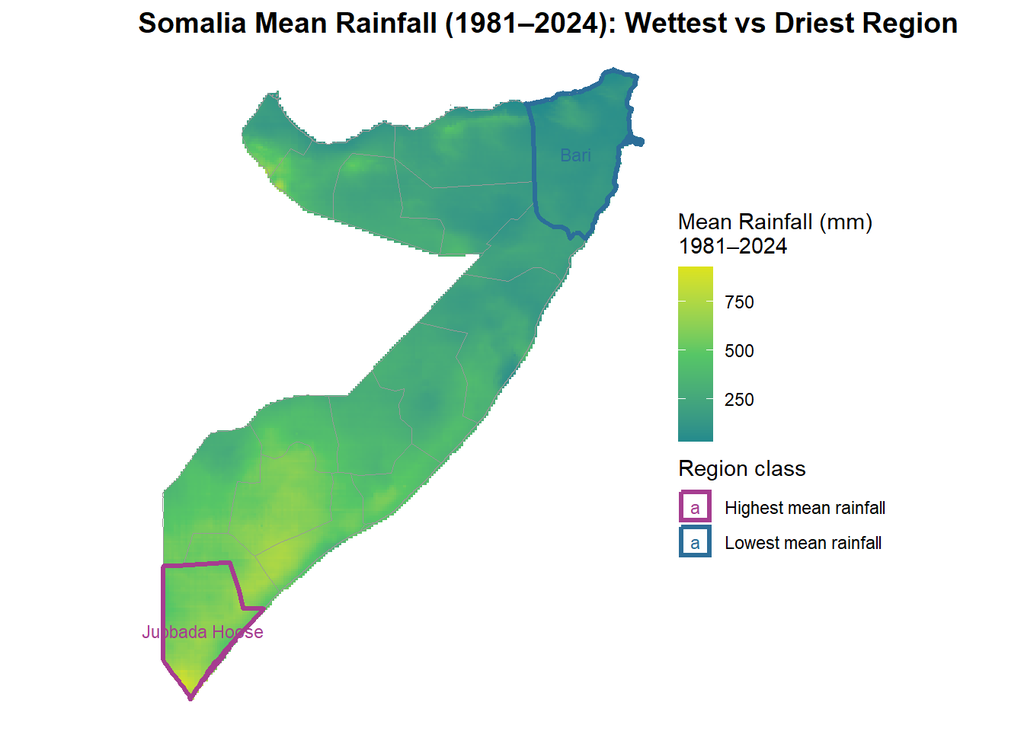

```r
# Plot: mean raster + grey regions + highlight highest/lowest
ggplot() +
  geom_spatraster(data = chirps_SOM_mean_1981_2024) +
  scale_fill_gradientn(
    colours = c("#228A8D", "#56C666", "#DDE31C"),
    na.value = "transparent",
    name = "Mean Rainfall (mm)\n1981–2024"
  ) +
  geom_sf(data = somalia_regions, fill = NA, color = "grey60", linewidth = 0.35) +
  geom_sf(
    data = subset(somalia_regions, hi_lo != "Other"),
    aes(color = hi_lo),
    fill = NA,
    linewidth = 1.2
  ) +
  scale_color_manual(
    values = c(
      "Highest mean rainfall" = "#A63D90",
      "Lowest mean rainfall" = "#2C6E99"
    ),
    name = "Region class"
  ) +
  geom_sf_text(
    data = subset(somalia_regions, hi_lo != "Other"),
    aes(label = NAME_1, color = hi_lo),
    size = 3
  ) +
  theme_void() +
  labs(
    title = "Somalia Mean Rainfall (1981–2024): Wettest vs Driest Region"
  ) +
  theme(
    plot.title = element_text(face = "bold", size = 14),
    legend.position = "right"
  )
```

# 6 Regional Trend Analysis: MK + Sen + OLS

```r
## Regional trend analysis: MK + Sen + OLS

region_trend <- region_ts_mean %>%
  group_by(Region) %>%
  summarise(
    mk_tau    = Kendall::MannKendall(mean_rain)$tau,
    mk_p      = Kendall::MannKendall(mean_rain)$sl,
    sen_slope = trend::sens.slope(mean_rain)$estimates,
    ols_slope = coef(lm(mean_rain ~ year))[2],
    ols_p     = summary(lm(mean_rain ~ year))$coefficients[2,4],
    .groups = "drop"
  ) %>%
  mutate(
    Trend_Class = case_when(
      mk_p < 0.05 & sen_slope > 0 ~ "Significant increase",
      mk_p < 0.05 & sen_slope < 0 ~ "Significant decrease",
      TRUE                        ~ "No significant trend"
    )
  ) %>%
  mutate(across(c(mk_tau, mk_p, sen_slope, ols_slope, ols_p), ~round(.x, 4))) %>%
  arrange(desc(sen_slope))

knitr::kable(
  region_trend,
  format = "html",
  caption = "Regional rainfall trend results in Somalia (1981–2024)"
) %>%
  kableExtra::kable_styling(
    full_width = TRUE,
    bootstrap_options = c("striped", "condensed", "hover")
  )
```

Regional rainfall trend results in Somalia (1981–2024)

| Region | mk_tau | mk_p | sen_slope | ols_slope | ols_p | Trend_Class |
| --- | --- | --- | --- | --- | --- | --- |
| Gedo | 0.0825 | 0.4361 | 1.3066 | 1.7279 | 0.4811 | No significant trend |
| Sool | 0.1416 | 0.1786 | 0.9839 | 0.9643 | 0.2275 | No significant trend |
| Togdheer | 0.1226 | 0.2448 | 0.9489 | 1.4758 | 0.1713 | No significant trend |
| Bari | 0.1459 | 0.1659 | 0.9091 | 1.0467 | 0.1087 | No significant trend |
| Sanaag | 0.0973 | 0.3574 | 0.7506 | 0.8976 | 0.2418 | No significant trend |
| Nugaal | 0.0507 | 0.6345 | 0.3366 | 0.4057 | 0.6349 | No significant trend |
| Bakool | 0.0211 | 0.8476 | 0.2662 | 0.4325 | 0.8442 | No significant trend |
| Hiiraan | 0.0063 | 0.9597 | 0.1907 | -0.0383 | 0.9817 | No significant trend |
| Galguduud | 0.0042 | 0.9758 | 0.1050 | -0.5453 | 0.6943 | No significant trend |
| Mudug | -0.0085 | 0.9436 | -0.0305 | -0.5717 | 0.6016 | No significant trend |
| Bay | -0.0169 | 0.8794 | -0.2397 | -0.2403 | 0.9226 | No significant trend |
| Woqooyi Galbeed | -0.0465 | 0.6636 | -0.3978 | -0.0533 | 0.9556 | No significant trend |
| Jubbada Dhexe | -0.0444 | 0.6784 | -0.8111 | -0.9789 | 0.6843 | No significant trend |
| Awdal | -0.1501 | 0.1538 | -1.2263 | -1.4070 | 0.1547 | No significant trend |
| Shabeellaha Dhexe | -0.1226 | 0.2448 | -1.7202 | -2.6070 | 0.1861 | No significant trend |
| Jubbada Hoose | -0.1163 | 0.2703 | -1.9277 | -1.9570 | 0.3438 | No significant trend |
| Shabeellaha Hoose | -0.2051 | 0.0509 | -2.4934 | -3.3673 | 0.1255 | No significant trend |
| Banaadir | -0.2347 | 0.0254 | -2.7761 | -3.2634 | 0.1195 | Significant decrease |

# 7 Regional Rainfall Trend CLassificaiton in Somalia

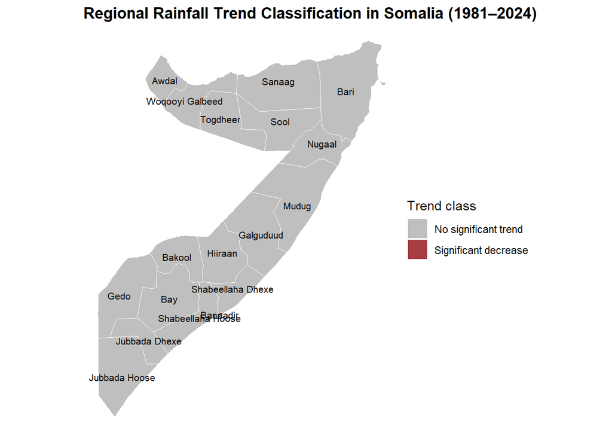

```r
somalia_regions <- left_join(
  somalia_regions,
  region_trend,
  by = c("NAME_1" = "Region")
)

ggplot(somalia_regions) +
  geom_sf(aes(fill = Trend_Class), color = "white", linewidth = 0.35) +
  geom_sf_text(aes(label = NAME_1), size = 2.8, color = "black") +
  scale_fill_manual(
    values = c(
      "Significant increase" = "#2C6E91",
      "Significant decrease" = "#A63D40",
      "No significant trend" = "grey75"
    ),
    name = "Trend class"
  ) +
  theme_void() +
  labs(title = "Regional Rainfall Trend Classification in Somalia (1981–2024)") +
  theme(
    plot.title = element_text(face = "bold", size = 13),
    legend.position = "right"
  )
```

# 8 FOASTAT DATA ANALYSIS

## 8.1 Foastat data Cleaning

```r
# Quick data checks
names(somalia_livestock_stocks_1981_2024)
```

```
##  [1] "domain_code"      "domain"           "area_code_m49"    "area"
##  [5] "element_code"     "element"          "item_code_cpc"    "species"
##  [9] "year_code"        "year"             "unit"             "value"
## [13] "flag"             "flag_description" "note"
```

```r
str(somalia_livestock_stocks_1981_2024)
```

```
## 'data.frame':    176 obs. of  15 variables:
##  $ domain_code     : chr  "QCL" "QCL" "QCL" "QCL" ...
##  $ domain          : chr  "Crops and livestock products" "Crops and livestock products" "Crops and livestock products" "Crops and livestock products" ...
##  $ area_code_m49   : int  706 706 706 706 706 706 706 706 706 706 ...
##  $ area            : chr  "Somalia" "Somalia" "Somalia" "Somalia" ...
##  $ element_code    : int  5111 5111 5111 5111 5111 5111 5111 5111 5111 5111 ...
##  $ element         : chr  "Stocks" "Stocks" "Stocks" "Stocks" ...
##  $ item_code_cpc   : num  2121 2111 2123 2122 2121 ...
##  $ species         : chr  "Camels" "Cattle" "Goats" "Sheep" ...
##  $ year_code       : int  1981 1981 1981 1981 1982 1982 1982 1982 1983 1983 ...
##  $ year            : int  1981 1981 1981 1981 1982 1982 1982 1982 1983 1983 ...
##  $ unit            : chr  "An" "An" "An" "An" ...
##  $ value           : int  6014000 4473000 18000000 10800000 6239000 4574000 19000000 10580000 6131000 4201000 ...
##  $ flag            : chr  "A" "A" "A" "A" ...
##  $ flag_description: chr  "Official figure" "Official figure" "Official figure" "Official figure" ...
##  $ note            : chr  "" "" "" "" ...
```

```r
summary(somalia_livestock_stocks_1981_2024)
```

```
##  domain_code           domain          area_code_m49     area
##  Length:176         Length:176         Min.   :706   Length:176
##  Class :character   Class :character   1st Qu.:706   Class :character
##  Mode  :character   Mode  :character   Median :706   Mode  :character
##                                        Mean   :706
##                                        3rd Qu.:706
##                                        Max.   :706
##   element_code    element          item_code_cpc    species
##  Min.   :5111   Length:176         Min.   :2111   Length:176
##  1st Qu.:5111   Class :character   1st Qu.:2119   Class :character
##  Median :5111   Mode  :character   Median :2122   Mode  :character
##  Mean   :5111                      Mean   :2119
##  3rd Qu.:5111                      3rd Qu.:2122
##  Max.   :5111                      Max.   :2123
##    year_code         year          unit               value
##  Min.   :1981   Min.   :1981   Length:176         Min.   : 3300000
##  1st Qu.:1992   1st Qu.:1992   Class :character   1st Qu.: 5750000
##  Median :2002   Median :2002   Mode  :character   Median : 7790554
##  Mean   :2002   Mean   :2002                      Mean   : 9370761
##  3rd Qu.:2013   3rd Qu.:2013                      3rd Qu.:12092360
##  Max.   :2024   Max.   :2024                      Max.   :20550000
##      flag           flag_description       note
##  Length:176         Length:176         Length:176
##  Class :character   Class :character   Class :character
##  Mode  :character   Mode  :character   Mode  :character
##
##
##
```

```r
# converting the the values as.numeric and year as.integer
somalia_livestock_stocks_1981_2024 <- somalia_livestock_stocks_1981_2024 %>%
  mutate(
    year  = as.integer(year),
    value = as.numeric(value),
    species = as.factor(species),
    species = as.factor(species)
  )

# Check duplicates by species-year (should usually be 1 per species per year)
dup_check <- somalia_livestock_stocks_1981_2024 %>%
  count(species, year) %>%
  filter(n > 1)

# Missing values overview
colSums(is.na(somalia_livestock_stocks_1981_2024))
```

```
##      domain_code           domain    area_code_m49             area
##                0                0                0                0
##     element_code          element    item_code_cpc          species
##                0                0                0                0
##        year_code             year             unit            value
##                0                0                0                0
##             flag flag_description             note
##                0                0                0
```

```r
# Flag distribution (data quality context)
somalia_livestock_stocks_1981_2024 %>%
  count(flag, flag_description, sort = TRUE)
```

```
##   flag                    flag_description   n
## 1    E                     Estimated value 101
## 2    A                     Official figure  45
## 3    I Value imputed by a receiving agency  27
## 4    X   Figure from external organization   3
```

## 8.2 Time series indicators

To characterize livestock stock dynamics over time (trend, volatility, and growth), we compute standard year-to-year change metrics within each species (item). After sorting by year, we derive: (i) absolute YoY change *`ΔVt=Vt−Vt−1`* (ii) YoY percent change *`gt=(Vt/Vt−1−1)×100`* and (iii) a baseline index (1981=100) *`It=(Vt/V1981)×100`*. These indicators enable cross-species comparison on both absolute and relative scales while preserving the original measurement unit (headcount).

**Results***:*

- **yoy_change (annual absolute change, heads)**: The largest absolute year-to-year declines are concentrated in the early 1990s and are strongest in small ruminants. Goats show the biggest shocks: in 1991 yoy_change = −4,500,000 (stocks drop from 18,500,000 to 14,000,000), followed by 1992 yoy_change = −4,000,000 (down to 10,000,000).
- Sheep also decline sharply in 1991 with yoy_change = −2,000,000 (13,000,000 → 11,000,000). The contraction is also visible in other species but at smaller magnitudes, including cattle in 1990 (yoy_change = −800,000, 4,800,000 → 4,000,000) and camels in 1991 (yoy_change = −500,000, 6,700,000 → 6,200,000).
- Immediately after the contraction, the series shows clear rebound jumps: cattle (1993) +900,000 (3,300,000 → 4,200,000), sheep (1993) +1,500,000 (10,000,000 → 11,500,000), and goats (1993) +1,000,000 (10,000,000 → 11,000,000). Overall, the time series is dominated by a sharp contraction (1990–1992) followed by a rebound (1993–1994), with the largest absolute shocks occurring in goats and sheep.
- **`yoy_pct` (Annual Growth/Decline Rate, %):** The strongest year-to-year percentage contractions are tightly concentrated in **1990–1992**, and they are most severe for **goats and sheep**. Goats experience the sharpest drops in **1991** and **1992**, indicating an unusually large contraction over two consecutive years. Sheep also show their steepest negative percentage change in **1991**, with continued decline into **1992**. Cattle show their largest percentage decline in **1990**, followed by another substantial negative rate in **1991**. Camels decline as well in **1991–1992**, but the percentage losses are clearly smaller than for the other species.
- The strongest positive percentage growth rates occur immediately after this contraction, with the most pronounced rebound in **1993–1994**. Cattle show the most intense recovery rate in **1993**, consistent with a rebound from a low point reached in 1992. Sheep show strong positive growth in **1993** and again in **1994**, indicating a two-year recovery phase. Goats also show a marked rebound in **1993** and **1994**, reversing part of the early-1990s decline. In contrast, camels exhibit only moderate positive growth rates across the rebound period, suggesting comparatively smoother adjustment.
- Overall, the `yoy_pct` series is dominated by a **high-volatility episode around the early 1990s**—a rapid contraction followed by a rapid recovery—while later decades show **much smaller year-to-year percentage movements**, even when livestock levels remain large
- **Index_1981 — long-run position relative to the 1981 baseline:** For `index_1981`, the results summarize the **long-run position of each herd relative to its own 1981 baseline**, so it’s the cleanest way to describe “where the series ends up” after all short-run volatility is absorbed. By 2024, **camels** sit at `index_1981 = 126.25833`, meaning the camel stock level is about **26% higher than in 1981**, while **cattle** end at `107.04699`, indicating a **modest net gain** of roughly **7% above** the baseline. In contrast, the small-ruminant series remain structurally below their starting point: **goats** end at `62.78391` (roughly **37% below** the 1981 level) and **sheep** at `73.96233` (about **26% below** baseline). In results terms, the index makes the long-run divergence explicit—**camels and cattle show net expansion over 1981–2024**, while **goats and sheep do not recover to baseline by 2024**, even though they exhibit periods of short-run rebound in the intermediate years.

```r
ts_tbl <- somalia_livestock_stocks_1981_2024 %>%
  arrange(species, year) %>%
  group_by(species) %>%
  mutate(
    yoy_change = value - lag(value),
    yoy_pct    = 100 * (value / lag(value) - 1),
    index_1981 = 100 * (value / first(value))
  ) %>%
  ungroup()

# Interactive table for the time-series indicators
DT::datatable(ts_tbl, rownames = FALSE, caption  = "Somalia livestock stocks (FAOSTAT): time-series indicators by species, 1981–2024",
  options  = list(pageLength = 25, scrollX = TRUE)
)
```

| domain_code | domain | area_code_m49 | area | element_code | element | item_code_cpc | species | year_code | year | unit | value | flag | flag_description | note | yoy_change | yoy_pct | index_1981 |
| --- | --- | --- | --- | --- | --- | --- | --- | --- | --- | --- | --- | --- | --- | --- | --- | --- | --- |
| QCL | Crops and livestock products | 706 | Somalia | 5111 | Stocks | 2121.01 | Camels | 1981 | 1981 | An | 6014000 | A | Official figure |  |  |  | 100 |
| QCL | Crops and livestock products | 706 | Somalia | 5111 | Stocks | 2121.01 | Camels | 1982 | 1982 | An | 6239000 | A | Official figure |  | 225000 | 3.741270369138672 | 103.7412703691387 |
| QCL | Crops and livestock products | 706 | Somalia | 5111 | Stocks | 2121.01 | Camels | 1983 | 1983 | An | 6131000 | A | Official figure |  | -108000 | -1.731046642090084 | 101.9454605919521 |
| QCL | Crops and livestock products | 706 | Somalia | 5111 | Stocks | 2121.01 | Camels | 1984 | 1984 | An | 6162000 | A | Official figure |  | 31000 | 0.5056271407600788 | 102.4609245094779 |
| QCL | Crops and livestock products | 706 | Somalia | 5111 | Stocks | 2121.01 | Camels | 1985 | 1985 | An | 6411000 | A | Official figure |  | 249000 | 4.040895813047718 | 106.6012637179913 |
| QCL | Crops and livestock products | 706 | Somalia | 5111 | Stocks | 2121.01 | Camels | 1986 | 1986 | An | 6378000 | A | Official figure |  | -33000 | -0.5147402901263476 | 106.052544063851 |
| QCL | Crops and livestock products | 706 | Somalia | 5111 | Stocks | 2121.01 | Camels | 1987 | 1987 | An | 6601000 | A | Official figure |  | 223000 | 3.496393853872681 | 109.7605586963751 |
| QCL | Crops and livestock products | 706 | Somalia | 5111 | Stocks | 2121.01 | Camels | 1988 | 1988 | An | 6841000 | A | Official figure |  | 240000 | 3.635812755643086 | 113.7512470901231 |
| QCL | Crops and livestock products | 706 | Somalia | 5111 | Stocks | 2121.01 | Camels | 1989 | 1989 | An | 6900000 | E | Estimated value |  | 59000 | 0.8624470106709525 | 114.7322913202527 |
| QCL | Crops and livestock products | 706 | Somalia | 5111 | Stocks | 2121.01 | Camels | 1990 | 1990 | An | 6700000 | E | Estimated value |  | -200000 | -2.898550724637683 | 111.4067176587962 |

[output cut: 166 more lines]

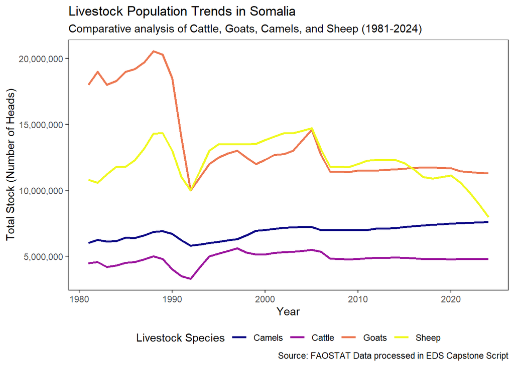

```r
# 1) Plot: levels trend time (stocks)
ggplot(ts_tbl, aes(x = year, y = value, color = species)) +
  geom_line(linewidth = 1) +
  scale_y_continuous(labels = label_comma()) +
  scale_color_viridis_d(option = "plasma", name = "Livestock Species") +
  labs(
    title = "Livestock Population Trends in Somalia",
    subtitle = "Comparative analysis of Cattle, Goats, Camels, and Sheep (1981-2024)",
    x = "Year",
    y = "Total Stock (Number of Heads)",
    caption = "Source: FAOSTAT Data processed in EDS Capstone Script"
  ) +
  theme_test() +
  theme(legend.position = "bottom")
```

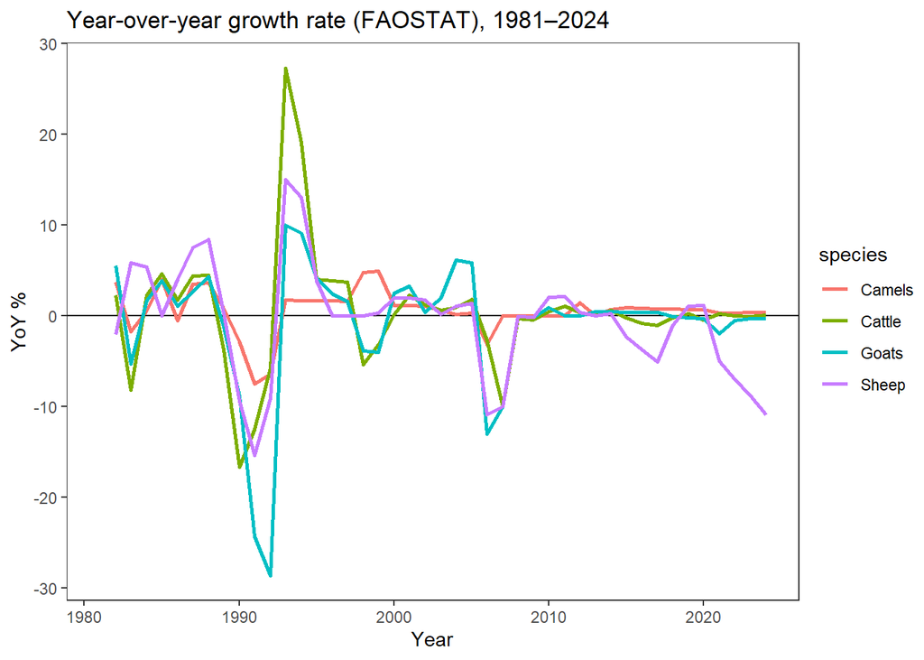

```r
# 2) Plot: growth rate (YoY %)
ggplot(ts_tbl, aes(x = year, y = yoy_pct, color= species)) +
  geom_hline(yintercept = 0) +
  geom_line(linewidth = 1) +
  theme_test()+
  scale_y_continuous(labels = label_comma()) +
  labs(
    title = "Year-over-year growth rate (FAOSTAT), 1981–2024",
    x = "Year", y = "YoY %"
  )
```

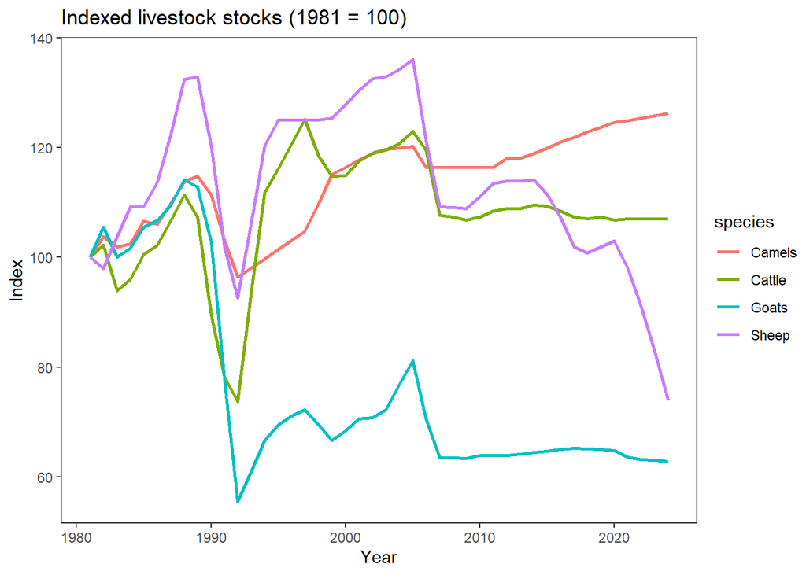

```r
# 3) Plot: index (1981 = 100) for comparison across animals
ggplot(ts_tbl, aes(x = year, y = index_1981, color = species)) +
  geom_line(linewidth = 1) +
theme_test()+
  labs(
    title = "Indexed livestock stocks (1981 = 100)",
    x = "Year", y = "Index"
  )
```

# 9 Exploratory summary of livestock stock distributions and trends

The livestock EDA shows that the four species differ clearly in both stock size and variability over 1981–2024. Goats have the highest average stock level (13.63 million) and also the largest variability (SD = 3.11 million; CV = 22.83%), indicating that goat stocks changed more strongly over time than the other species. Sheep also have relatively high stock levels (mean = 12.20 million) with moderate variability (CV = 12.72%). In contrast, camels and cattle are more stable, with lower coefficients of variation (7.58% and 9.77%, respectively), suggesting less fluctuation across the study period.

The histograms and boxplots support these results. Goat stocks show the widest spread and the clearest upper values, while sheep also display broad dispersion. Camel stocks are more tightly clustered, consistent with a relatively steady long-term increase. Cattle show a narrower distribution centered around about 4.8–5.0 million, though with a few lower years.

The extremes table highlights important turning points. 1992 is the lowest stock year for camels, cattle, and goats, suggesting a common livestock shock or contraction during the early 1990s. For sheep, the minimum occurs in 2024, while the highest value occurs in 2005. Goat stocks reached their maximum much earlier, in 1988, and then declined substantially afterward. Camels, by contrast, reached their maximum in 2024, which is consistent with sustained long-run growth.

The trend table confirms these differences statistically. Camels show a clear and significant long-term increase (Sen’s slope ≈ +35,108 head/year; MK p < 0.001). Goats show a strong and significant long-term decrease (Sen’s slope ≈ −92,597 head/year; MK p < 0.001). Cattle show no statistically significant trend, indicating relative long-run stability. Sheep show a negative OLS slope, but the Mann–Kendall result is not significant at the 5% level, so this decline should be interpreted cautiously. Overall, the EDA suggests a long-run divergence in Somalia’s livestock structure: camels increased, goats declined, cattle remained broadly stable, and sheep showed a weaker downward tendency.

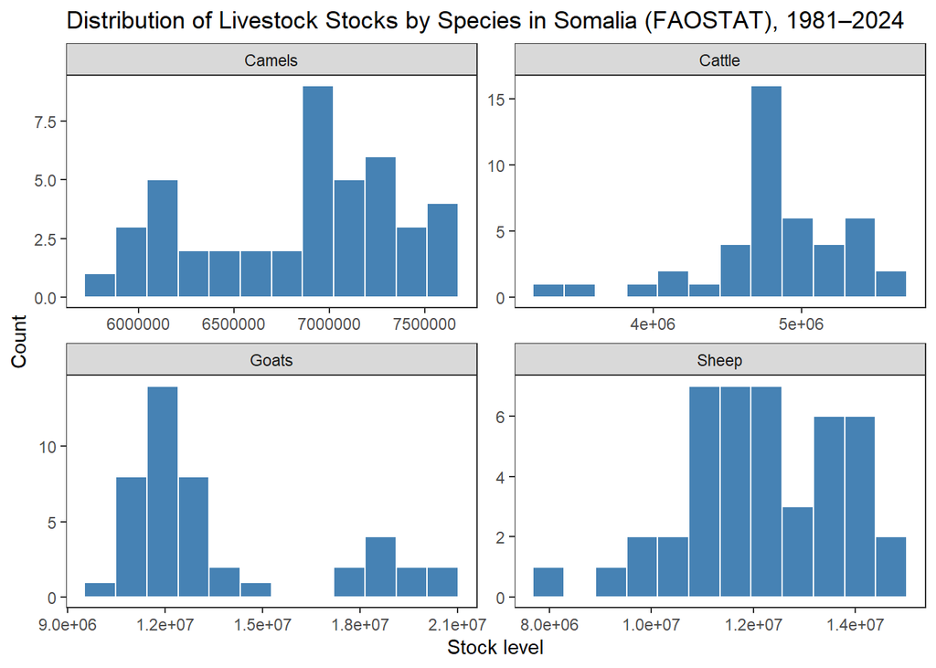

```r
# 1) Distribution check: histogram by species
ggplot(somalia_livestock_stocks_1981_2024, aes(x = value)) +
  geom_histogram(bins = 12, fill = "steelblue", color = "white") +
  facet_wrap(~ species, scales = "free") +
  theme_test() +
  labs(
    title = "Distribution of Livestock Stocks by Species in Somalia (FAOSTAT), 1981–2024",
    x = "Stock level",
    y = "Count"
  )
```

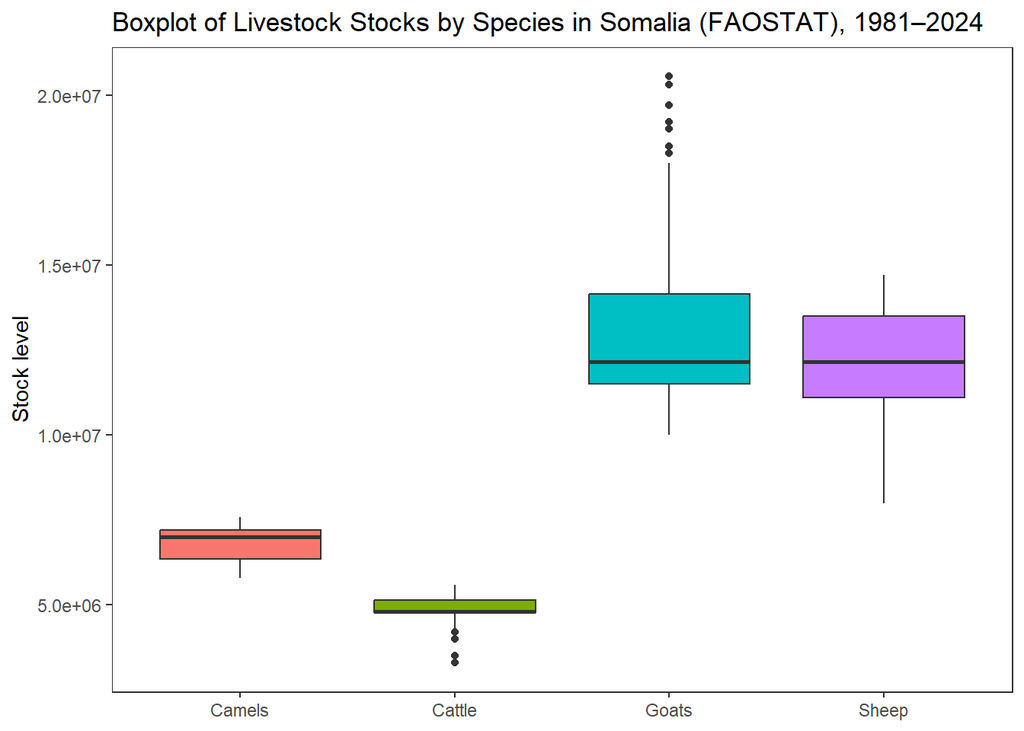

```r
# 2) Distribution check: boxplot by species
ggplot(somalia_livestock_stocks_1981_2024, aes(x = species, y = value, fill = species)) +
  geom_boxplot() +
  theme_test() +
  labs(
    title = "Boxplot of Livestock Stocks by Species in Somalia (FAOSTAT), 1981–2024",
    x = NULL,
    y = "Stock level"
  ) +
  theme(legend.position = "none")
```

```r
# 3) Summary table by species
livestock_summary_table <- somalia_livestock_stocks_1981_2024 %>%
  group_by(species) %>%
  summarise(
    observations = n(),
    mean_stock = round(mean(value, na.rm = TRUE), 2),
    sd_stock = round(sd(value, na.rm = TRUE), 2),
    min_stock = round(min(value, na.rm = TRUE), 2),
    median_stock = round(median(value, na.rm = TRUE), 2),
    max_stock = round(max(value, na.rm = TRUE), 2),
    cv_percent = round(100 * sd(value, na.rm = TRUE) / mean(value, na.rm = TRUE), 2),
    .groups = "drop"
  ) %>%
  arrange(desc(mean_stock))

knitr::kable(
  livestock_summary_table,
  format = "html",
  caption = "Summary Statistics for Somalia Livestock Stocks by Species (FAOSTAT), 1981–2024"
) %>%
  kableExtra::kable_styling(
    full_width = TRUE,
    bootstrap_options = c("striped", "condensed", "hover")
  )
```

Summary Statistics for Somalia Livestock Stocks by Species (FAOSTAT), 1981–2024

| species | observations | mean_stock | sd_stock | min_stock | median_stock | max_stock | cv_percent |
| --- | --- | --- | --- | --- | --- | --- | --- |
| Goats | 44 | 13630095 | 3111657.1 | 10000000 | 12150000 | 20550000 | 22.83 |
| Sheep | 44 | 12197630 | 1551168.4 | 7987932 | 12144907 | 14700000 | 12.72 |
| Camels | 44 | 6840469 | 518421.0 | 5800000 | 7000000 | 7593176 | 7.58 |
| Cattle | 44 | 4814849 | 470614.8 | 3300000 | 4800000 | 5600000 | 9.77 |

```r
# 4) Extremes table by species
livestock_extremes_table <- somalia_livestock_stocks_1981_2024 %>%
  group_by(species) %>%
  summarise(
    lowest_year = year[which.min(value)],
    lowest_stock = round(min(value, na.rm = TRUE), 2),
    highest_year = year[which.max(value)],
    highest_stock = round(max(value, na.rm = TRUE), 2),
    .groups = "drop"
  )

knitr::kable(
  livestock_extremes_table,
  format = "html",
  caption = "Lowest and Highest Livestock Stock Years by Species in Somalia (FAOSTAT), 1981–2024"
) %>%
  kableExtra::kable_styling(
    full_width = TRUE,
    bootstrap_options = c("striped", "condensed", "hover")
  )
```

Lowest and Highest Livestock Stock Years by Species in Somalia (FAOSTAT), 1981–2024

| species | lowest_year | lowest_stock | highest_year | highest_stock |
| --- | --- | --- | --- | --- |
| Camels | 1992 | 5800000 | 2024 | 7593176 |
| Cattle | 1992 | 3300000 | 1997 | 5600000 |
| Goats | 1992 | 10000000 | 1988 | 20550000 |
| Sheep | 2024 | 7987932 | 2005 | 14700000 |

```r
# 5) Species trend table
livestock_species_trend_table <- somalia_livestock_stocks_1981_2024 %>%
  group_by(species) %>%
  summarise(
    ols_slope = coef(lm(value ~ year))[2],
    ols_p = summary(lm(value ~ year))$coefficients[2, 4],
    mk_tau = Kendall::MannKendall(value)$tau,
    mk_p = Kendall::MannKendall(value)$sl,
    sen_slope = trend::sens.slope(value)$estimates,
    .groups = "drop"
  ) %>%
  mutate(
    Trend_Class = case_when(
      mk_p < 0.05 & sen_slope > 0 ~ "Significant increase",
      mk_p < 0.05 & sen_slope < 0 ~ "Significant decrease",
      TRUE ~ "No significant trend"
    ),
    across(c(ols_slope, ols_p, mk_tau, mk_p, sen_slope), ~ round(.x, 4))
  ) %>%
  arrange(desc(sen_slope))

knitr::kable(
  livestock_species_trend_table,
  format = "html",
  caption = "Trend Results for Somalia Livestock Stocks by Species (FAOSTAT), 1981–2024"
) %>%
  kableExtra::kable_styling(
    full_width = TRUE,
    bootstrap_options = c("striped", "condensed", "hover")
  )
```

Trend Results for Somalia Livestock Stocks by Species (FAOSTAT), 1981–2024

| species | ols_slope | ols_p | mk_tau | mk_p | sen_slope | Trend_Class |
| --- | --- | --- | --- | --- | --- | --- |
| Camels | 34387.43 | 0.0000 | 0.7328 | 0.0000 | 35108.049 | Significant increase |
| Cattle | 10695.12 | 0.0545 | 0.0895 | 0.4007 | 3867.521 | No significant trend |
| Sheep | -43237.52 | 0.0170 | -0.1948 | 0.0654 | -49040.764 | No significant trend |
| Goats | -182333.04 | 0.0000 | -0.5003 | 0.0000 | -92597.311 | Significant decrease |

**Model**: Livestock–climate linkages were evaluated using a generalized additive model (GAM) to allow non-linear relationships and lagged rainfall effects. The response variable was log-transformed FAOSTAT national livestock stocks (camels, cattle, goats, sheep). Predictors included (i) a species-specific smooth of time to capture long-run, non-linear trajectories and (ii) species-specific smooth terms for national CHIRPS rainfall anomalies at 0-, 1-, and 2-year lags. Models were estimated in mgcv using REML for smoothing-parameter selection. This approach is designed to detect “curved” (non-linear) responses and delayed effects rather than forcing a straight-line relationshi.

**Method** : Annual CHIRPS national rainfall anomalies were used to construct lagged anomaly terms (t, t−1, t−2), which were then merged by year to the FAOSTAT livestock series. Early years without complete lag structure were excluded, yielding n = 168 observations. Stocks were modeled on the log scale to stabilize variance and support multiplicative interpretation. Model adequacy was assessed with standard GAM diagnostics (residual plots, fitted vs observed, and basis-dimension checks). Because the rainfall series is national (not regional), the model tests whether national rainfall departures from average are associated with national livestock dynamics.

**Results and interpretation**: The GAM explains most of the variation in livestock stocks (adjusted R² = 0.979; deviance explained = 98.4%), indicating that the model reproduces the observed national livestock trajectories closely. Species-level differences are strong (all p < 2×10⁻¹⁶), confirming persistent level differences in national stocks among camels, cattle, goats, and sheep.

The time smooths are highly significant for all species (all p < 2×10⁻¹⁶), showing that each livestock series follows a non-linear trajectory over 1981–2024. Cattle, goats, and sheep show substantial non-linearity (edf ≈ 7.82, 8.21, and 6.90, respectively), consistent with multi-phase dynamics rather than a single monotonic trend. Camels show a much simpler time structure (edf ≈ 1.0), consistent with a smoother long-run trajectory. In practical terms, the dominant signal in the data is “time structure” (multi-decadal changes and regime-like shifts), not short-term rainfall variability.

In contrast, the rainfall anomaly smooths (lags 0–2 years) are not statistically significant for most species–lag combinations at the 5% level. The only rainfall-related term close to conventional significance is the same-year anomaly effect for goats (p ≈ 0.055), while all other lag terms show weak evidence of association (p-values generally well above 0.1). This means that, at the national scale and after accounting for each species’ long-run trajectory, there is limited statistical evidence that year-to-year national rainfall anomalies (including 1–2 year delays) systematically explain additional variation in livestock stocks.

*Substantive meaning for the capstone question*: the model supports the conclusion that Somalia’s national livestock stocks exhibit strong, species-specific non-linear change over time, but it does not provide strong evidence that national mean rainfall anomalies are a major independent predictor of those national stock dynamics once time structure is included. This does not imply rainfall is unimportant biologically; rather, it indicates that national averaging may mask spatially localized climate–forage–herd mechanisms, and that livestock changes are also shaped by non-climatic drivers (conflict, markets, mobility constraints, disease, policy, and data-quality/estimation regimes). A clearer rainfall–livestock signal may emerge in regional analyses or in models that use spatial rainfall summaries aligned with pastoral systems rather than a single national mean.

```r
# 1) Ensure correct types in livestock table
somalia_livestock_stocks_1981_2024 <- somalia_livestock_stocks_1981_2024 %>%
  mutate(
    year    = as.integer(year),     # year as integer
    value   = as.numeric(value),    # stocks as numeric
    species = as.factor(species)    # species as factor (grouping variable)
  )

# 2) Build national rainfall anomaly lags
rain_lags <- som_ts_mean %>%
  select(year, anomaly) %>%         # keep only what we need
  arrange(year) %>%                 # guarantee time order
  mutate(
    anom_l0 = anomaly,              # same-year anomaly (t)
    anom_l1 = lag(anomaly, 1),      # 1-year lag (t-1)
    anom_l2 = lag(anomaly, 2)       # 2-year lag (t-2)
  ) %>%
  select(year, anom_l0, anom_l1, anom_l2)

# 3) Merge livestock with rainfall lags by year
dat_gam <- somalia_livestock_stocks_1981_2024 %>%
  inner_join(rain_lags, by = "year") %>%   # match years
  filter(!is.na(anom_l2)) %>%              # drop early years where lags are missing
  arrange(species, year) %>%               # sort within species
  mutate(
    log_value = log(value)                 # log-transform stocks for stability
  )

# 4) Fit GAM: species-specific non-linear time trend + species-specific non-linear rainfall effects (lags 0–2)
gam_fit <- mgcv::gam(
  log_value ~ species +
    s(year,    by = species, k = 10) +
    s(anom_l0, by = species, k = 6) +
    s(anom_l1, by = species, k = 6) +
    s(anom_l2, by = species, k = 6),
  data   = dat_gam,
  method = "REML"
)

# 5) Print model results
summary(gam_fit)
```

```
##
## Family: gaussian
## Link function: identity
##
## Formula:
## log_value ~ species + s(year, by = species, k = 10) + s(anom_l0,
##     by = species, k = 6) + s(anom_l1, by = species, k = 6) +
##     s(anom_l2, by = species, k = 6)
##
## Parametric coefficients:
##                Estimate Std. Error t value Pr(>|t|)
## (Intercept)   15.740601   0.009682 1625.73   <2e-16 ***
## speciesCattle -0.355801   0.013693  -25.98   <2e-16 ***
## speciesGoats   0.649170   0.013693   47.41   <2e-16 ***
## speciesSheep   0.573659   0.013693   41.90   <2e-16 ***
## ---
## Signif. codes:  0 '***' 0.001 '**' 0.01 '*' 0.05 '.' 0.1 ' ' 1
##
## Approximate significance of smooth terms:
##                            edf Ref.df      F p-value
## s(year):speciesCamels    1.000  1.000 39.966  <2e-16 ***
## s(year):speciesCattle    7.820  8.638  8.718  <2e-16 ***
## s(year):speciesGoats     8.214  8.820 39.841  <2e-16 ***
## s(year):speciesSheep     6.903  7.980 17.658  <2e-16 ***
## s(anom_l0):speciesCamels 1.000  1.000  0.171  0.6801
## s(anom_l0):speciesCattle 1.000  1.000  2.052  0.1544
## s(anom_l0):speciesGoats  1.000  1.000  3.747  0.0551 .
## s(anom_l0):speciesSheep  1.000  1.000  1.266  0.2626
## s(anom_l1):speciesCamels 1.000  1.000  0.038  0.8453
## s(anom_l1):speciesCattle 1.000  1.000  0.000  0.9863
## s(anom_l1):speciesGoats  1.139  1.258  1.149  0.2352
## s(anom_l1):speciesSheep  1.307  1.530  0.149  0.7273
## s(anom_l2):speciesCamels 1.000  1.000  0.012  0.9130
## s(anom_l2):speciesCattle 1.000  1.000  0.425  0.5155
## s(anom_l2):speciesGoats  1.491  1.792  0.349  0.6083
## s(anom_l2):speciesSheep  1.000  1.000  0.075  0.7846
## ---
## Signif. codes:  0 '***' 0.001 '**' 0.01 '*' 0.05 '.' 0.1 ' ' 1
##
## R-sq.(adj) =  0.979   Deviance explained = 98.4%
## -REML = -126.04  Scale est. = 0.0039373  n = 168
```

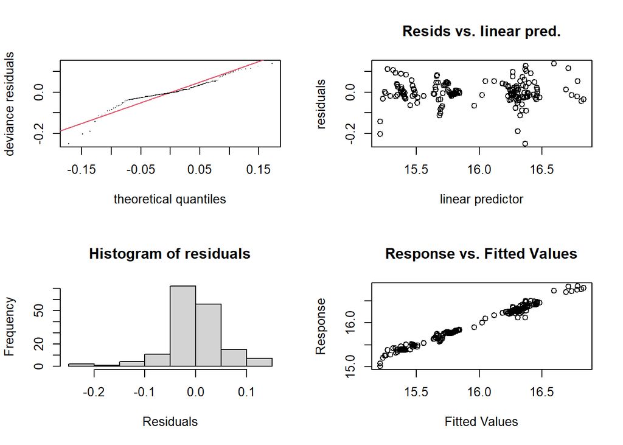

```
##
## Method: REML   Optimizer: outer newton
## full convergence after 13 iterations.
## Gradient range [-5.84854e-06,6.966972e-05]
## (score -126.045 & scale 0.003937252).
## Hessian positive definite, eigenvalue range [8.707624e-07,74.46165].
## Model rank =  100 / 100
##
## Basis dimension (k) checking results. Low p-value (k-index<1) may
## indicate that k is too low, especially if edf is close to k'.
##
##                            k'  edf k-index p-value
## s(year):speciesCamels    9.00 1.00    0.42  <2e-16 ***
## s(year):speciesCattle    9.00 7.82    0.42  <2e-16 ***
## s(year):speciesGoats     9.00 8.21    0.42  <2e-16 ***
## s(year):speciesSheep     9.00 6.90    0.42  <2e-16 ***
## s(anom_l0):speciesCamels 5.00 1.00    0.52  <2e-16 ***
## s(anom_l0):speciesCattle 5.00 1.00    0.52  <2e-16 ***
## s(anom_l0):speciesGoats  5.00 1.00    0.52  <2e-16 ***
## s(anom_l0):speciesSheep  5.00 1.00    0.52  <2e-16 ***
## s(anom_l1):speciesCamels 5.00 1.00    0.56  <2e-16 ***
## s(anom_l1):speciesCattle 5.00 1.00    0.56  <2e-16 ***
## s(anom_l1):speciesGoats  5.00 1.14    0.56  <2e-16 ***
## s(anom_l1):speciesSheep  5.00 1.31    0.56  <2e-16 ***
## s(anom_l2):speciesCamels 5.00 1.00    0.52  <2e-16 ***
## s(anom_l2):speciesCattle 5.00 1.00    0.52  <2e-16 ***
## s(anom_l2):speciesGoats  5.00 1.49    0.52  <2e-16 ***
## s(anom_l2):speciesSheep  5.00 1.00    0.52  <2e-16 ***
## ---
## Signif. codes:  0 '***' 0.001 '**' 0.01 '*' 0.05 '.' 0.1 ' ' 1
```

```r
# 6) Diagnostics (checks residual patterns, k adequacy, etc.)
par(mfrow = c(2, 2))
gam.check(gam_fit)
```

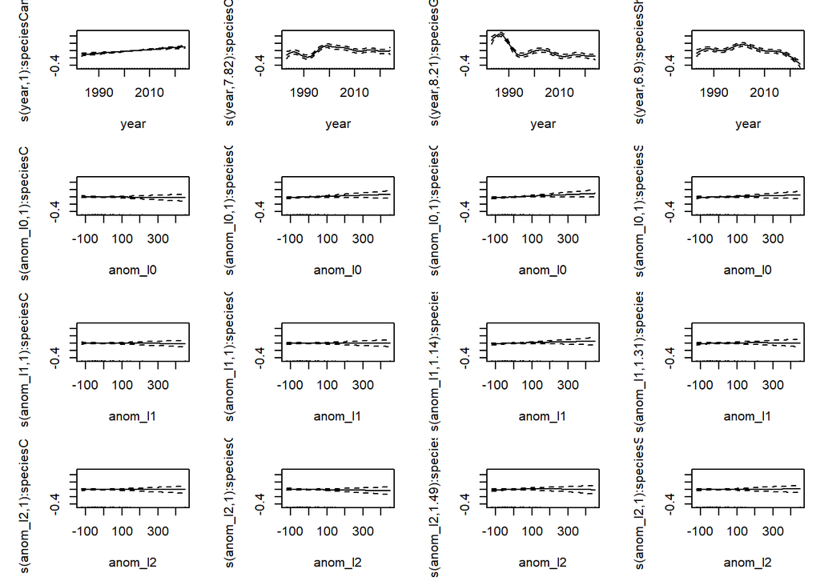

```r
par(mfrow = c(1, 1))

# 7) Partial effect plots (non-linear shapes by species and by lag)
#    These are the key plots to interpret: how livestock responds across anomaly values (wet/dry)
par(mfrow = c(3, 2))
plot(gam_fit, pages = 1, shade = TRUE, seWithMean = TRUE)
```

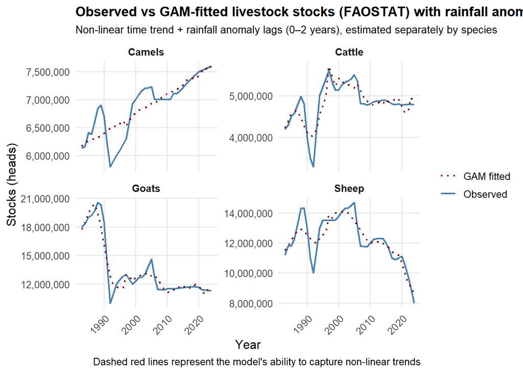

```r
par(mfrow = c(1, 1))

# 8) Observed vs fitted stocks (back-transform to original scale)
  dat_gam <- dat_gam %>%
  mutate(
    pred_log   = predict(gam_fit, newdata = dat_gam, type = "response"),
    pred_value = exp(pred_log))


#plot
ggplot(dat_gam, aes(x = year)) +
  geom_line(aes(y = value,     color = "Observed"),   linewidth = 0.8) +
  geom_line(aes(y = pred_value, color = "GAM fitted"), linewidth = 0.8, linetype = "dotted") +
  facet_wrap(~ species, scales = "free_y", ncol = 2) +
  scale_color_manual(values = c("Observed" = "steelblue", "GAM fitted" = "darkred"),name = NULL ) +
  scale_y_continuous(labels = label_comma()) +
  labs(
    title = "Observed vs GAM-fitted livestock stocks (FAOSTAT) with rainfall anomaly lags (CHIRPS)",
    subtitle = "Non-linear time trend + rainfall anomaly lags (0–2 years), estimated separately by species",
    x = "Year",
    y = "Stocks (heads)",
    caption = "Dashed red lines represent the model's ability to capture non-linear trends"

  ) +

  theme_minimal(base_size = 12) +
  theme(
    plot.title = element_text(face = "bold", size = 13),
    plot.subtitle = element_text(size = 10),
    axis.text.x = element_text(angle = 45, hjust = 1),
    strip.text = element_text(face = "bold"),
    legend.position = "right",
    panel.grid.minor = element_blank()
  )
```

# 10 Discussion

The results indicate that Somalia’s rainfall patterns are dominated by strong interannual variability rather than a consistent long-term trend. Both the OLS and Mann–Kendall tests show little evidence of a monotonic rainfall trend over the study period.

Livestock population trends differ substantially by species. Camels show a significant long-term increase, while goats show a strong decline and cattle remain relatively stable. These differences suggest that livestock adaptation strategies may vary across species.

The GAM analysis indicates that rainfall anomalies alone do not strongly explain national livestock stock changes once long-term time dynamics are included. This suggests that additional drivers such as conflict, market changes, disease outbreaks, and pastoral mobility constraints may play an important role.

## 10.1 Limitations

Several limitations should be considered when interpreting these results.

First, livestock data from FAOSTAT are national aggregates and may include estimated values, especially during periods of limited data reporting. Second, rainfall was analyzed at the national level, which may mask important local climate variability affecting pastoral systems. Third, other drivers such as conflict, land-use change, livestock disease, and market dynamics were not explicitly modeled in this analysis.

Future research could integrate regional livestock data and spatially explicit climate variables to better capture localized climate–livestock relationships.

## 10.2 Policy Implications

Improving climate resilience in Somalia’s pastoral sector requires better integration of climate monitoring and livestock management systems. Early-warning systems, drought preparedness strategies, and improved rangeland management can help reduce vulnerability to rainfall variability.

In addition, strengthening livestock data collection at regional levels would allow policymakers to better understand how climate variability affects pastoral systems across different ecological zones.

# 11 Conclusion

This study analyzed long-term rainfall variability and livestock population dynamics in Somalia using CHIRPS climate data and FAOSTAT livestock statistics from 1981 to 2024.

Results show that rainfall variability is characterized primarily by strong year-to-year fluctuations rather than a long-term trend. Livestock populations exhibit species-specific trajectories, with camels increasing significantly, goats declining, and cattle remaining relatively stable.

Statistical modeling suggests that national rainfall anomalies alone do not strongly explain livestock population changes once long-term time patterns are considered. These findings highlight the importance of considering both climate and socio-economic drivers when analyzing pastoral system dynamics.

Understanding these dynamics can support more effective climate adaptation strategies for Somalia’s pastoral sector.